# examples_0406

And then, since multiplication is commutative, the factors can be written in any order. In this case, the correct answer is:

$$y=(x+6)(x+8)^2(x+2)^2(x-3)$$

A polynomial is sketched below.

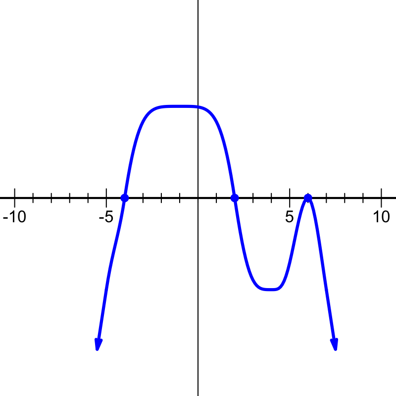

Which polynomial (in factored form) best matches the sketch?

$y=-(x-6)^2(x+4)(x-2)$$y=(x-6)^2(x+4)(x-2)$$y=-(x-6)^2(x+4)^2(x-2)$$y=(x-6)^2(x+4)^2(x-2)$

If a polynomial has a factor of $x-r$, then there will be an $x$-intercept at point $(r,0)$.

In this case, the roots (the $x$-intercepts) are at:

$$-4,\,2,\,6$$

Thus, the factors are $x+4$ and $x-2$ and $x-6$. Notice, the $x$-intercepts where the curve "bounces" off the $x$ axis correspond to an even multiplicity, in this case a multiplicity of 2. So, we know the curve could be represented by the function below:

$$y=a(x+4)(x-2)(x-6)^2$$

where $a$ is some constant.

Lastly, we need to determine whether $a$ should be positive or negative. In this problem, either $a=1$ or $a=-1$. To determine this, look at the right side of the graph. Specifically, we are considering the [end behavior of polynomials](https://www.khanacademy.org/math/algebra2/x2ec2f6f830c9fb89:poly-graphs/x2ec2f6f830c9fb89:poly-end-behavior/a/end-behavior-of-polynomials). Notice that once $x$ is larger than $6$, all the factors will be positive, so only $a$ will dictate whether the function on the right side is positive or negative.

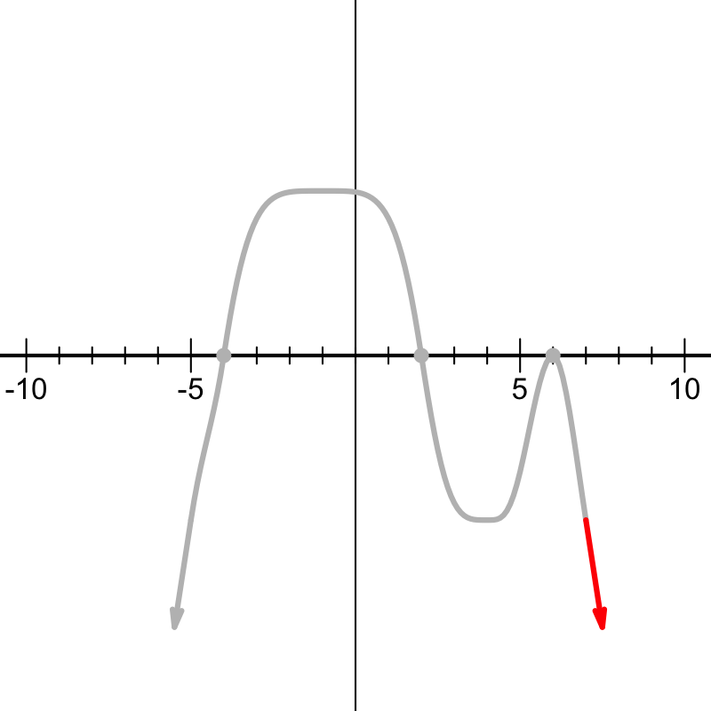

Notice, on the right side, the function is heading down. I guess more importantly, as $x\to \infty$ we see the function is negative. This implies that $a$ is negative. So, in this case, $a=-1$.

$$y=-(x+4)(x-2)(x-6)^2$$

And then, since multiplication is commutative, the factors can be written in any order. In this case, the correct answer is:

$$y=-(x-6)^2(x+4)(x-2)$$

A polynomial is sketched below.

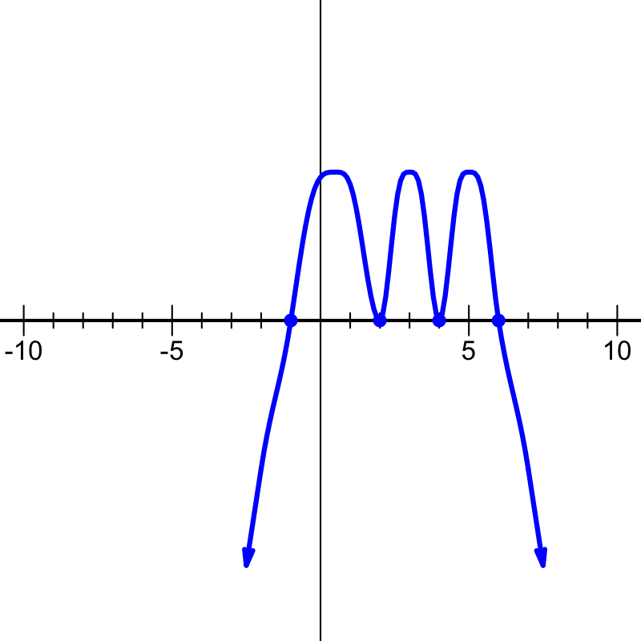

Which polynomial (in factored form) best matches the sketch?

$y=(x-6)(x-2)^2(x+1)(x-4)^2$$y=-(x-6)(x-2)(x+1)^2(x-4)$$y=(x-6)(x-2)(x+1)^2(x-4)$$y=-(x-6)(x-2)^2(x+1)(x-4)^2$

If a polynomial has a factor of $x-r$, then there will be an $x$-intercept at point $(r,0)$.

In this case, the roots (the $x$-intercepts) are at:

$$-1,\,2,\,4,\,6$$

Thus, the factors are $x+1$ and $x-2$ and $x-4$ and $x-6$. Notice, the $x$-intercepts where the curve "bounces" off the $x$ axis correspond to an even multiplicity, in this case a multiplicity of 2. So, we know the curve could be represented by the function below:

$$y=a(x+1)(x-2)^2(x-4)^2(x-6)$$

where $a$ is some constant.

Lastly, we need to determine whether $a$ should be positive or negative. In this problem, either $a=1$ or $a=-1$. To determine this, look at the right side of the graph. Specifically, we are considering the [end behavior of polynomials](https://www.khanacademy.org/math/algebra2/x2ec2f6f830c9fb89:poly-graphs/x2ec2f6f830c9fb89:poly-end-behavior/a/end-behavior-of-polynomials). Notice that once $x$ is larger than $6$, all the factors will be positive, so only $a$ will dictate whether the function on the right side is positive or negative.

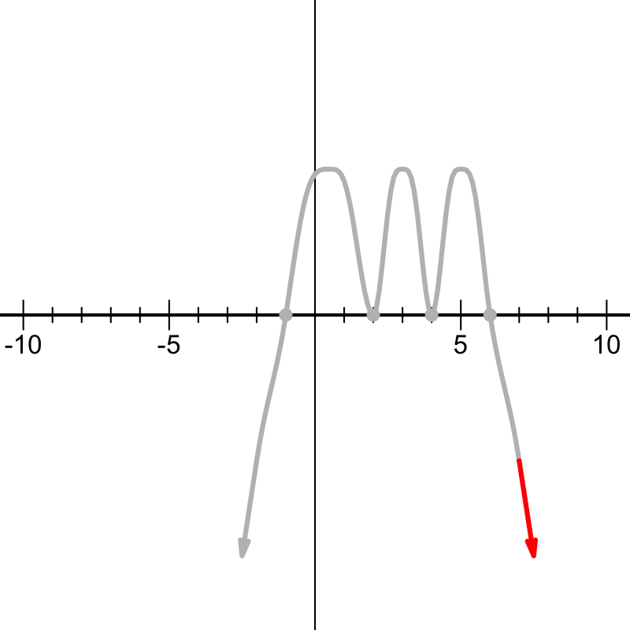

Notice, on the right side, the function is heading down. I guess more importantly, as $x\to \infty$ we see the function is negative. This implies that $a$ is negative. So, in this case, $a=-1$.

$$y=-(x+1)(x-2)^2(x-4)^2(x-6)$$

And then, since multiplication is commutative, the factors can be written in any order. In this case, the correct answer is:

$$y=-(x-6)(x-2)^2(x+1)(x-4)^2$$

A polynomial is sketched below.

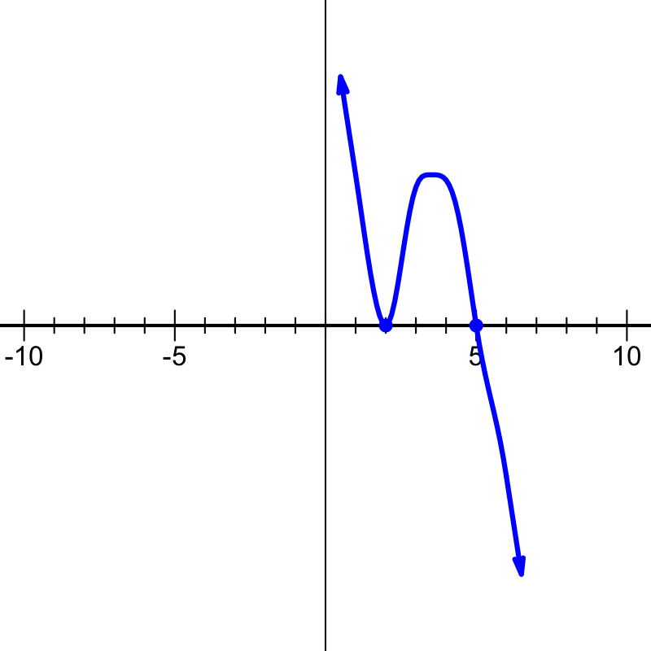

Which polynomial (in factored form) best matches the sketch?

$y=(x-2)^2(x-5)$$y=-(x-2)^2(x-5)$$y=(x-2)^2(x-5)^2$$y=-(x-2)^2(x-5)^2$

If a polynomial has a factor of $x-r$, then there will be an $x$-intercept at point $(r,0)$.

In this case, the roots (the $x$-intercepts) are at:

$$2,\,5$$

Thus, the factors are $x-2$ and $x-5$. Notice, the $x$-intercepts where the curve "bounces" off the $x$ axis correspond to an even multiplicity, in this case a multiplicity of 2. So, we know the curve could be represented by the function below:

$$y=a(x-2)^2(x-5)$$

where $a$ is some constant.

Lastly, we need to determine whether $a$ should be positive or negative. In this problem, either $a=1$ or $a=-1$. To determine this, look at the right side of the graph. Specifically, we are considering the [end behavior of polynomials](https://www.khanacademy.org/math/algebra2/x2ec2f6f830c9fb89:poly-graphs/x2ec2f6f830c9fb89:poly-end-behavior/a/end-behavior-of-polynomials). Notice that once $x$ is larger than $5$, all the factors will be positive, so only $a$ will dictate whether the function on the right side is positive or negative.

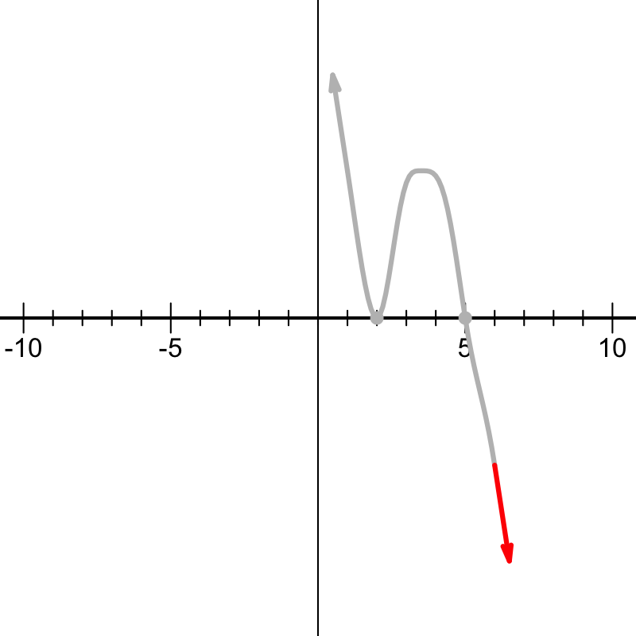

Notice, on the right side, the function is heading down. I guess more importantly, as $x\to \infty$ we see the function is negative. This implies that $a$ is negative. So, in this case, $a=-1$.

$$y=-(x-2)^2(x-5)$$

A polynomial is sketched below.

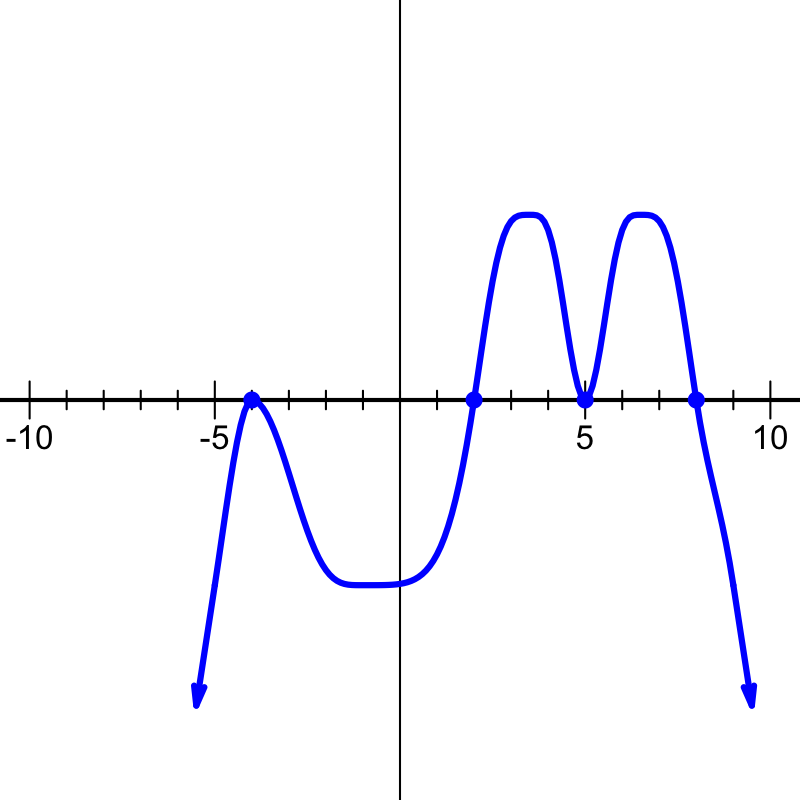

Which polynomial (in factored form) best matches the sketch?

$y=(x-5)^2(x+4)^2(x-2)(x-8)$$y=(x-5)^2(x+4)(x-2)(x-8)$$y=-(x-5)^2(x+4)(x-2)(x-8)$$y=-(x-5)^2(x+4)^2(x-2)(x-8)$

If a polynomial has a factor of $x-r$, then there will be an $x$-intercept at point $(r,0)$.

In this case, the roots (the $x$-intercepts) are at:

$$-4,\,2,\,5,\,8$$

Thus, the factors are $x+4$ and $x-2$ and $x-5$ and $x-8$. Notice, the $x$-intercepts where the curve "bounces" off the $x$ axis correspond to an even multiplicity, in this case a multiplicity of 2. So, we know the curve could be represented by the function below:

$$y=a(x+4)^2(x-2)(x-5)^2(x-8)$$

where $a$ is some constant.

Lastly, we need to determine whether $a$ should be positive or negative. In this problem, either $a=1$ or $a=-1$. To determine this, look at the right side of the graph. Specifically, we are considering the [end behavior of polynomials](https://www.khanacademy.org/math/algebra2/x2ec2f6f830c9fb89:poly-graphs/x2ec2f6f830c9fb89:poly-end-behavior/a/end-behavior-of-polynomials). Notice that once $x$ is larger than $8$, all the factors will be positive, so only $a$ will dictate whether the function on the right side is positive or negative.

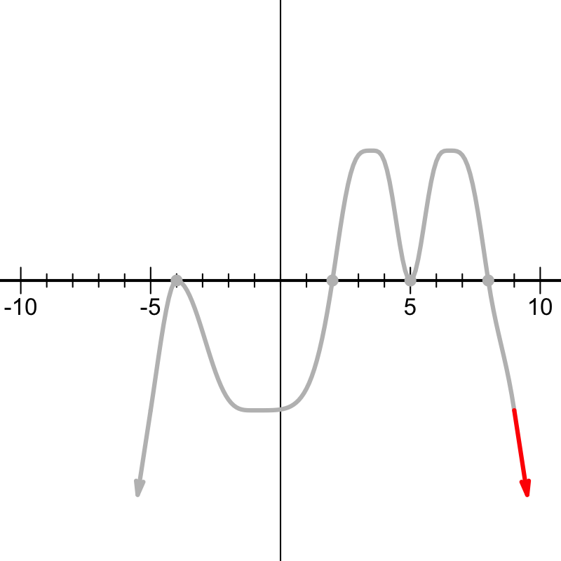

Notice, on the right side, the function is heading down. I guess more importantly, as $x\to \infty$ we see the function is negative. This implies that $a$ is negative. So, in this case, $a=-1$.

$$y=-(x+4)^2(x-2)(x-5)^2(x-8)$$

And then, since multiplication is commutative, the factors can be written in any order. In this case, the correct answer is:

$$y=-(x-5)^2(x+4)^2(x-2)(x-8)$$

A polynomial is sketched below.

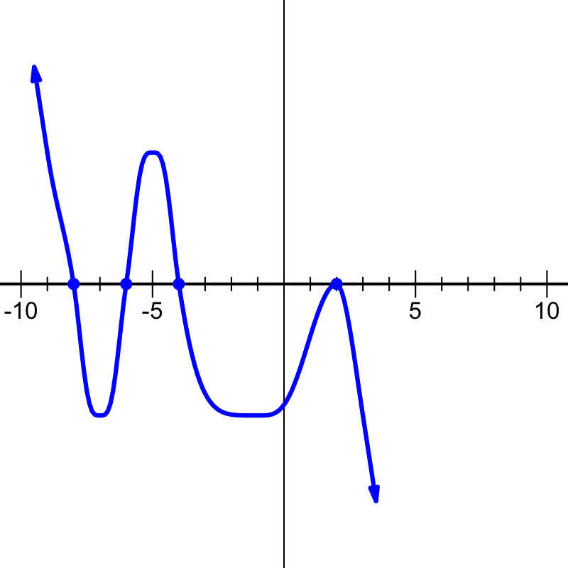

Which polynomial (in factored form) best matches the sketch?

$y=(x+8)(x+4)^2(x-2)^2(x+6)$$y=-(x+8)(x+4)^2(x-2)^2(x+6)$$y=(x+8)(x+4)(x-2)^2(x+6)$$y=-(x+8)(x+4)(x-2)^2(x+6)$

If a polynomial has a factor of $x-r$, then there will be an $x$-intercept at point $(r,0)$.

In this case, the roots (the $x$-intercepts) are at:

$$-8,\,-6,\,-4,\,2$$

Thus, the factors are $x+8$ and $x+6$ and $x+4$ and $x-2$. Notice, the $x$-intercepts where the curve "bounces" off the $x$ axis correspond to an even multiplicity, in this case a multiplicity of 2. So, we know the curve could be represented by the function below:

$$y=a(x+8)(x+6)(x+4)(x-2)^2$$

where $a$ is some constant.

Lastly, we need to determine whether $a$ should be positive or negative. In this problem, either $a=1$ or $a=-1$. To determine this, look at the right side of the graph. Specifically, we are considering the [end behavior of polynomials](https://www.khanacademy.org/math/algebra2/x2ec2f6f830c9fb89:poly-graphs/x2ec2f6f830c9fb89:poly-end-behavior/a/end-behavior-of-polynomials). Notice that once $x$ is larger than $2$, all the factors will be positive, so only $a$ will dictate whether the function on the right side is positive or negative.

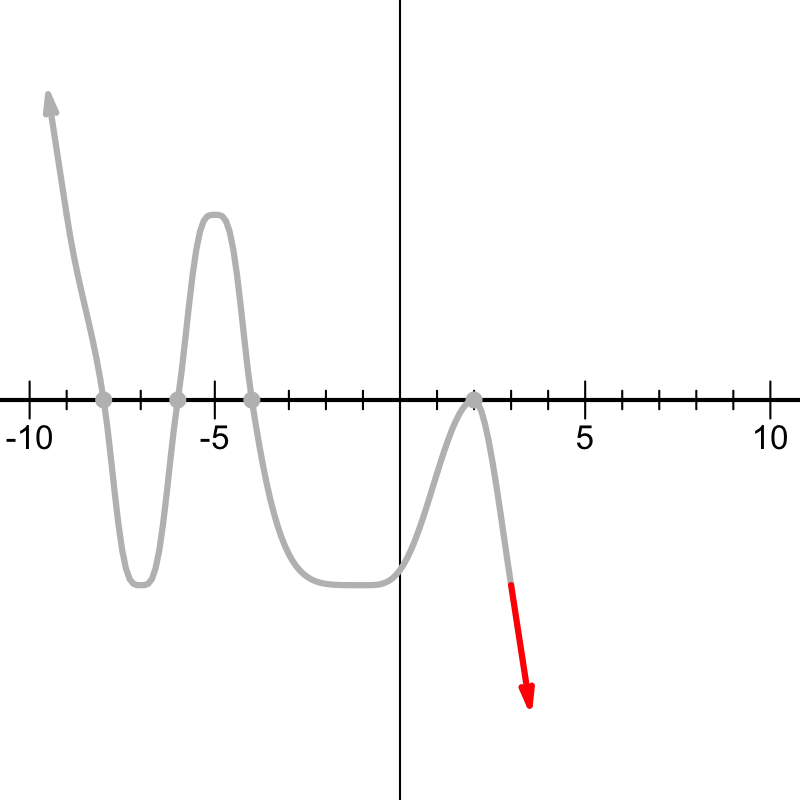

Notice, on the right side, the function is heading down. I guess more importantly, as $x\to \infty$ we see the function is negative. This implies that $a$ is negative. So, in this case, $a=-1$.

$$y=-(x+8)(x+6)(x+4)(x-2)^2$$

And then, since multiplication is commutative, the factors can be written in any order. In this case, the correct answer is:

$$y=-(x+8)(x+4)(x-2)^2(x+6)$$

A polynomial is sketched below.

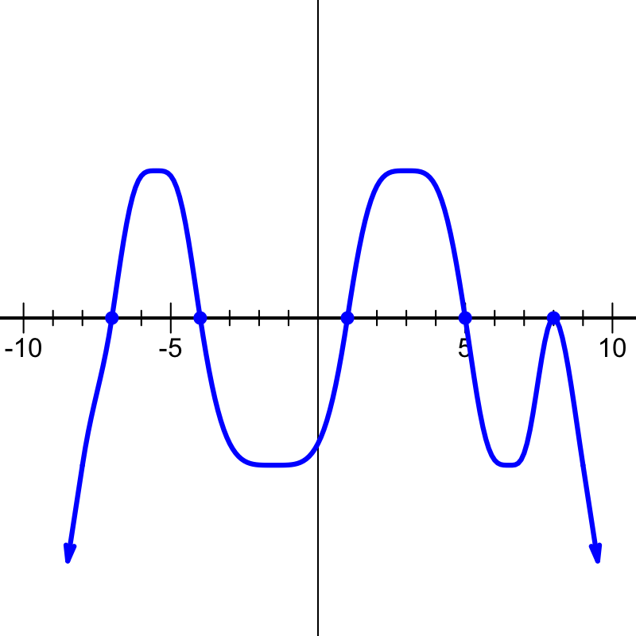

Which polynomial (in factored form) best matches the sketch?

$y=(x+7)(x-5)(x+4)(x-8)^2(x-1)$$y=-(x+7)(x-5)(x+4)(x-8)^2(x-1)$$y=(x+7)^2(x-5)^2(x+4)(x-8)(x-1)^2$$y=-(x+7)^2(x-5)^2(x+4)(x-8)(x-1)^2$

If a polynomial has a factor of $x-r$, then there will be an $x$-intercept at point $(r,0)$.

In this case, the roots (the $x$-intercepts) are at:

$$-7,\,-4,\,1,\,5,\,8$$

Thus, the factors are $x+7$ and $x+4$ and $x-1$ and $x-5$ and $x-8$. Notice, the $x$-intercepts where the curve "bounces" off the $x$ axis correspond to an even multiplicity, in this case a multiplicity of 2. So, we know the curve could be represented by the function below:

$$y=a(x+7)(x+4)(x-1)(x-5)(x-8)^2$$

where $a$ is some constant.

Lastly, we need to determine whether $a$ should be positive or negative. In this problem, either $a=1$ or $a=-1$. To determine this, look at the right side of the graph. Specifically, we are considering the [end behavior of polynomials](https://www.khanacademy.org/math/algebra2/x2ec2f6f830c9fb89:poly-graphs/x2ec2f6f830c9fb89:poly-end-behavior/a/end-behavior-of-polynomials). Notice that once $x$ is larger than $8$, all the factors will be positive, so only $a$ will dictate whether the function on the right side is positive or negative.

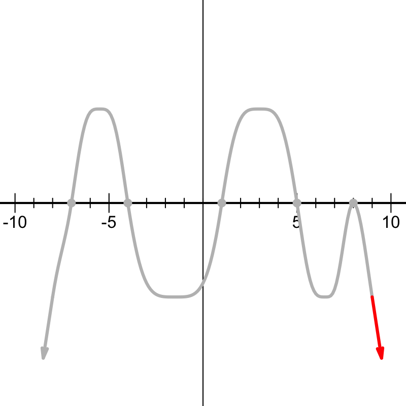

Notice, on the right side, the function is heading down. I guess more importantly, as $x\to \infty$ we see the function is negative. This implies that $a$ is negative. So, in this case, $a=-1$.

$$y=-(x+7)(x+4)(x-1)(x-5)(x-8)^2$$

And then, since multiplication is commutative, the factors can be written in any order. In this case, the correct answer is:

$$y=-(x+7)(x-5)(x+4)(x-8)^2(x-1)$$

A polynomial is sketched below.

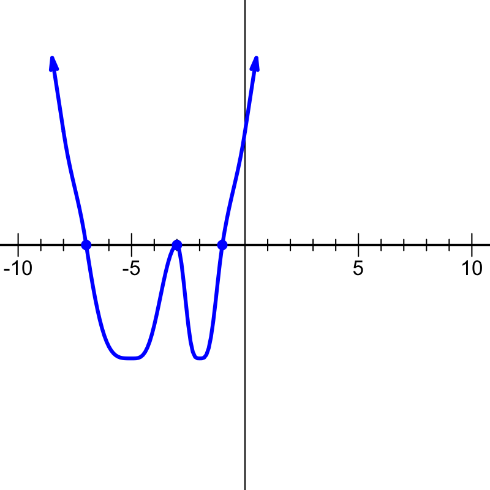

Which polynomial (in factored form) best matches the sketch?

$y=(x+3)(x+1)^2(x+7)^2$$y=(x+3)^2(x+1)(x+7)$$y=-(x+3)^2(x+1)(x+7)$$y=-(x+3)(x+1)^2(x+7)^2$

If a polynomial has a factor of $x-r$, then there will be an $x$-intercept at point $(r,0)$.

In this case, the roots (the $x$-intercepts) are at:

$$-7,\,-3,\,-1$$

Thus, the factors are $x+7$ and $x+3$ and $x+1$. Notice, the $x$-intercepts where the curve "bounces" off the $x$ axis correspond to an even multiplicity, in this case a multiplicity of 2. So, we know the curve could be represented by the function below:

$$y=a(x+7)(x+3)^2(x+1)$$

where $a$ is some constant.

Lastly, we need to determine whether $a$ should be positive or negative. In this problem, either $a=1$ or $a=-1$. To determine this, look at the right side of the graph. Specifically, we are considering the [end behavior of polynomials](https://www.khanacademy.org/math/algebra2/x2ec2f6f830c9fb89:poly-graphs/x2ec2f6f830c9fb89:poly-end-behavior/a/end-behavior-of-polynomials). Notice that once $x$ is larger than $-1$, all the factors will be positive, so only $a$ will dictate whether the function on the right side is positive or negative.

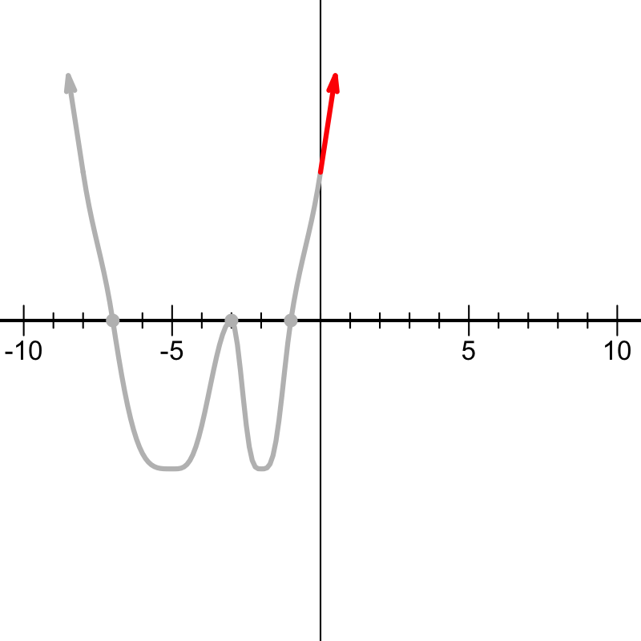

Notice, on the right side, the function is heading up. I guess more importantly, as $x\to \infty$ we see the function is positive. This implies that $a$ is positive. So, in this case, $a=1$.

$$y=(x+7)(x+3)^2(x+1)$$

And then, since multiplication is commutative, the factors can be written in any order. In this case, the correct answer is:

$$y=(x+3)^2(x+1)(x+7)$$

A polynomial is sketched below.

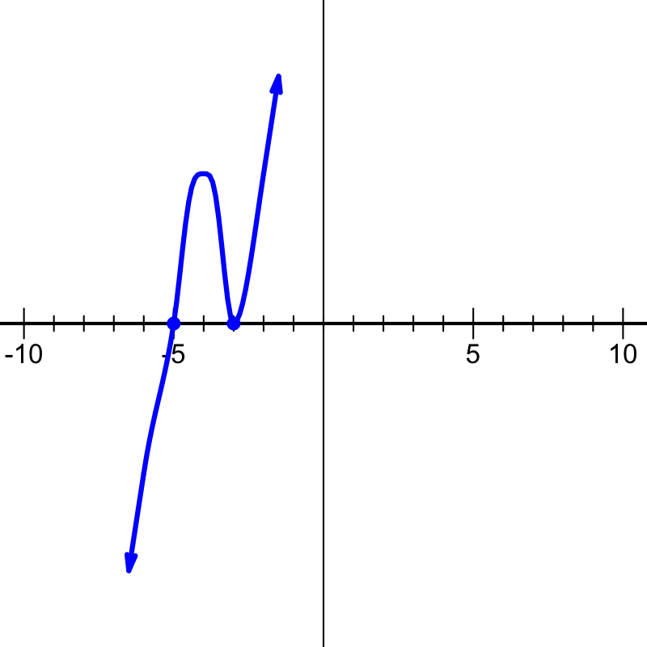

Which polynomial (in factored form) best matches the sketch?

$y=(x+5)^2(x+3)^2$$y=-(x+5)(x+3)^2$$y=(x+5)(x+3)^2$$y=-(x+5)^2(x+3)^2$

If a polynomial has a factor of $x-r$, then there will be an $x$-intercept at point $(r,0)$.

In this case, the roots (the $x$-intercepts) are at:

$$-5,\,-3$$

Thus, the factors are $x+5$ and $x+3$. Notice, the $x$-intercepts where the curve "bounces" off the $x$ axis correspond to an even multiplicity, in this case a multiplicity of 2. So, we know the curve could be represented by the function below:

$$y=a(x+5)(x+3)^2$$

where $a$ is some constant.

Lastly, we need to determine whether $a$ should be positive or negative. In this problem, either $a=1$ or $a=-1$. To determine this, look at the right side of the graph. Specifically, we are considering the [end behavior of polynomials](https://www.khanacademy.org/math/algebra2/x2ec2f6f830c9fb89:poly-graphs/x2ec2f6f830c9fb89:poly-end-behavior/a/end-behavior-of-polynomials). Notice that once $x$ is larger than $-3$, all the factors will be positive, so only $a$ will dictate whether the function on the right side is positive or negative.

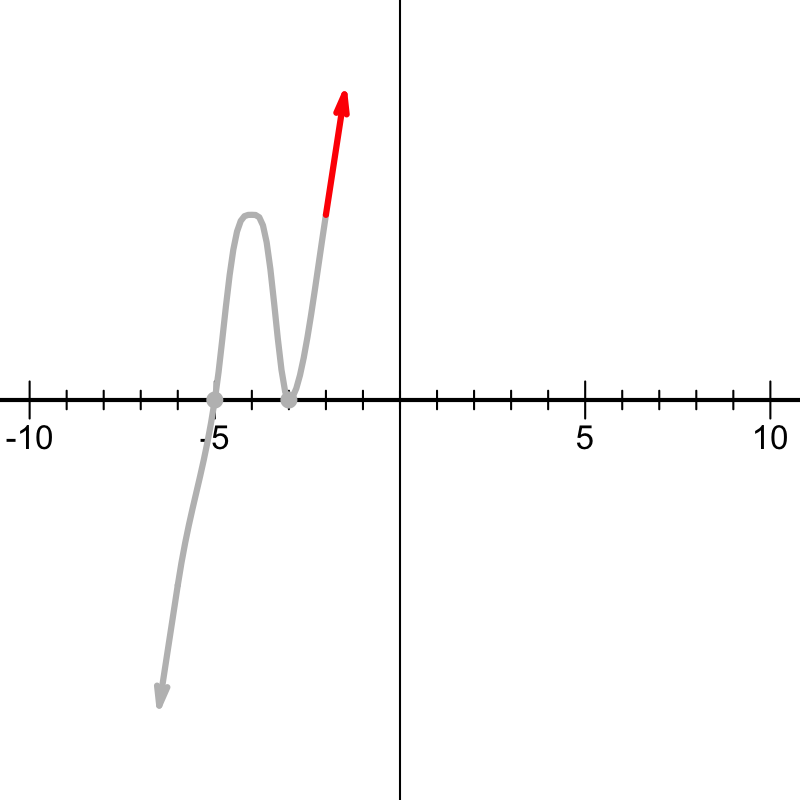

Notice, on the right side, the function is heading up. I guess more importantly, as $x\to \infty$ we see the function is positive. This implies that $a$ is positive. So, in this case, $a=1$.

$$y=(x+5)(x+3)^2$$

A polynomial is sketched below.

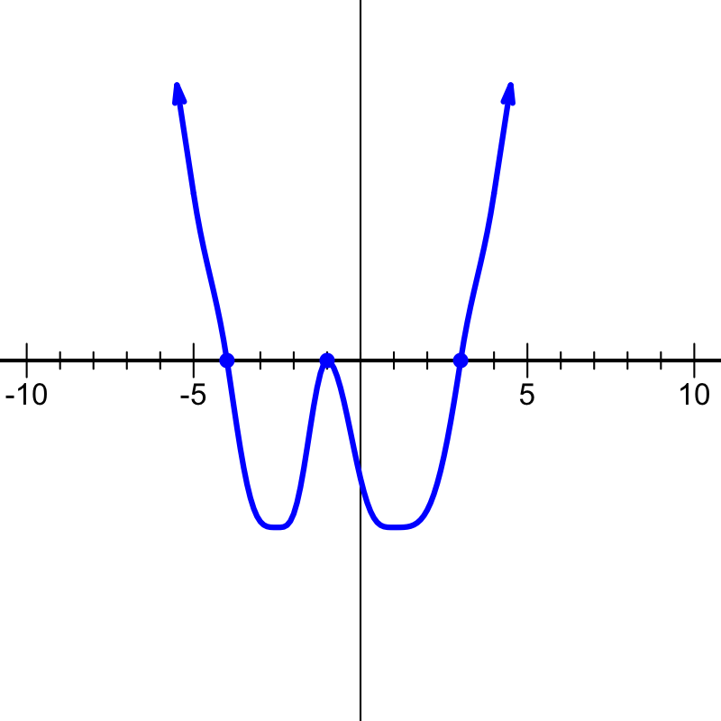

Which polynomial (in factored form) best matches the sketch?

$y=-(x+1)^2(x+4)(x-3)$$y=(x+1)^2(x+4)(x-3)$$y=-(x+1)(x+4)^2(x-3)$$y=(x+1)(x+4)^2(x-3)$

If a polynomial has a factor of $x-r$, then there will be an $x$-intercept at point $(r,0)$.

In this case, the roots (the $x$-intercepts) are at:

$$-4,\,-1,\,3$$

Thus, the factors are $x+4$ and $x+1$ and $x-3$. Notice, the $x$-intercepts where the curve "bounces" off the $x$ axis correspond to an even multiplicity, in this case a multiplicity of 2. So, we know the curve could be represented by the function below:

$$y=a(x+4)(x+1)^2(x-3)$$

where $a$ is some constant.

Lastly, we need to determine whether $a$ should be positive or negative. In this problem, either $a=1$ or $a=-1$. To determine this, look at the right side of the graph. Specifically, we are considering the [end behavior of polynomials](https://www.khanacademy.org/math/algebra2/x2ec2f6f830c9fb89:poly-graphs/x2ec2f6f830c9fb89:poly-end-behavior/a/end-behavior-of-polynomials). Notice that once $x$ is larger than $3$, all the factors will be positive, so only $a$ will dictate whether the function on the right side is positive or negative.

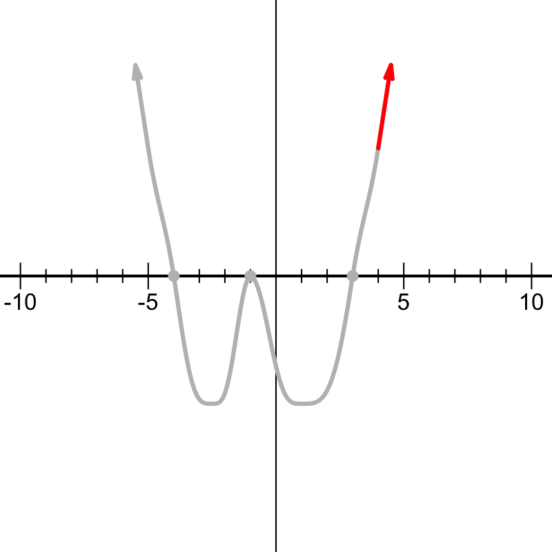

Notice, on the right side, the function is heading up. I guess more importantly, as $x\to \infty$ we see the function is positive. This implies that $a$ is positive. So, in this case, $a=1$.

$$y=(x+4)(x+1)^2(x-3)$$

And then, since multiplication is commutative, the factors can be written in any order. In this case, the correct answer is:

$$y=(x+1)^2(x+4)(x-3)$$

A polynomial, $p(x)$, is given in factored form.
$$p(x)~=~-(x+4)^{2}\cdot
(x-9)$$

Which of the following graphs matches $y=p(x)$?

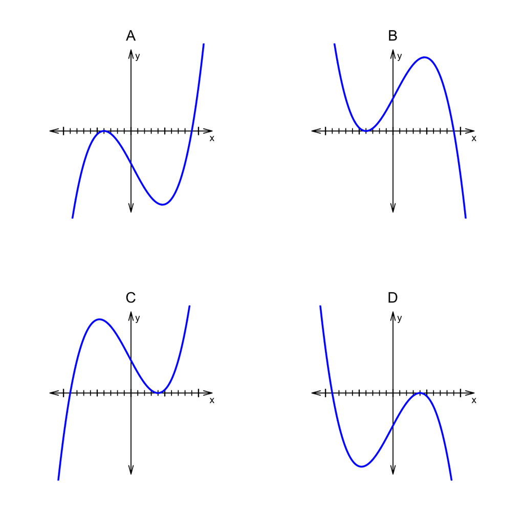

ABCD

First, consider the end behavior. If you expanded the polynomial into standard form, the highest-degree term would be $-x^{3}$.

$$p(x)~=~-x^{3}+\ldots$$

The highest degree term has a negative coefficient and an odd degree, so the end behavior is **"up,down"**. Or, more formally, $\lim\limits_{x\to-\infty} p(x) ~=~ \infty$ and $\lim\limits_{x\to\infty} p(x) ~=~ -\infty$.

Next, we consider the roots. From the factored form, $p(x)~=~-(x+4)^{2}\cdot (x-9)$, it is easy to see (see [zero-product property](https://en.wikipedia.org/wiki/Zero-product_property)) that $x=-4$ or $x=9$ makes the polynomial output 0.

$$p(-4)~=~-(-4+4)^{2}\cdot
(-4-9)~=~0$$
$$p(9)~=~-(9+4)^{2}\cdot
(9-9)~=~0$$

We predict that at $x=-4$ there is a double root (multiplicity of 2) because the corresponding factor is squared. Graphically, we expect the curve to "bounce" off the $x$ axis at $x=-4$. At the other root, we expect the curve to cut through the $x$ axis.

Anyway, based on this analysis, we can produce a [sign](https://en.wikipedia.org/wiki/Sign_function) graph of the polynomial.

| $x$ interval or value | sign analysis of $p(x)~=~-(x+4)^{2}\cdot (x-9)$ | sign |
| --- | --- | --- |
| $(-\infty,-4)$ | $-(\mathrm{neg})^{2}\cdot (\mathrm{neg})$ | $1$ |
| $-4$ | $-(\mathrm{zero})^{2}\cdot (\mathrm{neg})$ | $0$ |
| $(-4,9)$ | $-(\mathrm{pos})^{2}\cdot (\mathrm{neg})$ | $1$ |
| $9$ | $-(\mathrm{pos})^{2}\cdot (\mathrm{zero})$ | $0$ |
| $(9,\infty)$ | $-(\mathrm{pos})^{2}\cdot (\mathrm{pos})$ | $-1$ |

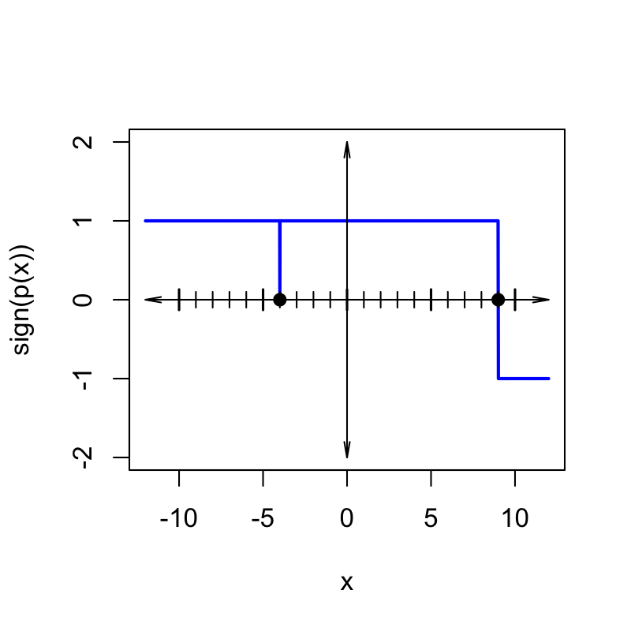

And only one option matches.

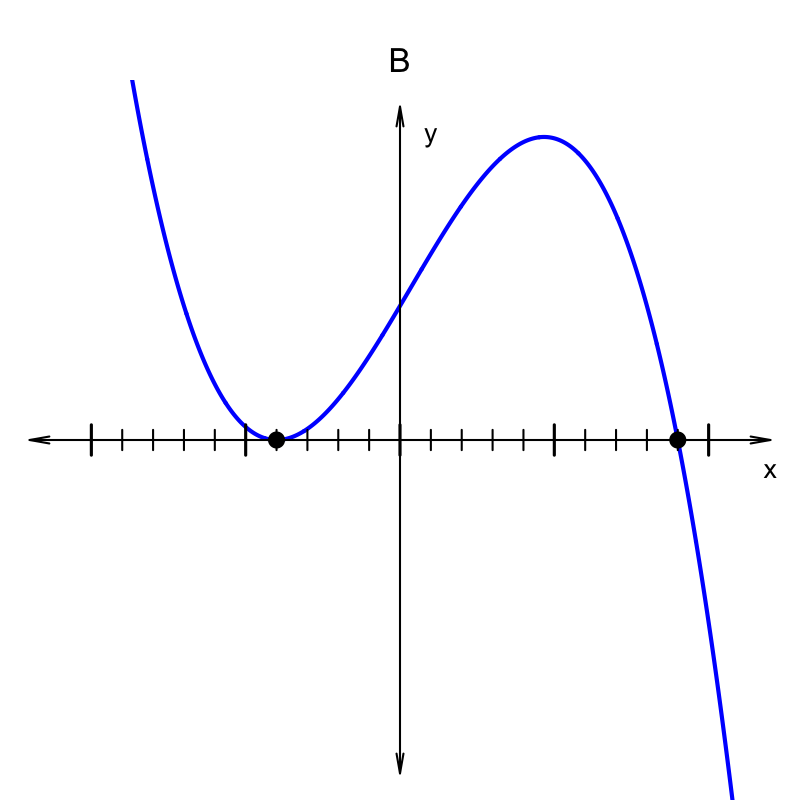

A polynomial, $p(x)$, is given in factored form.
$$p(x)~=~(x+2)\cdot
(x-1)^{2}\cdot (x-7)$$

Which of the following graphs matches $y=p(x)$?

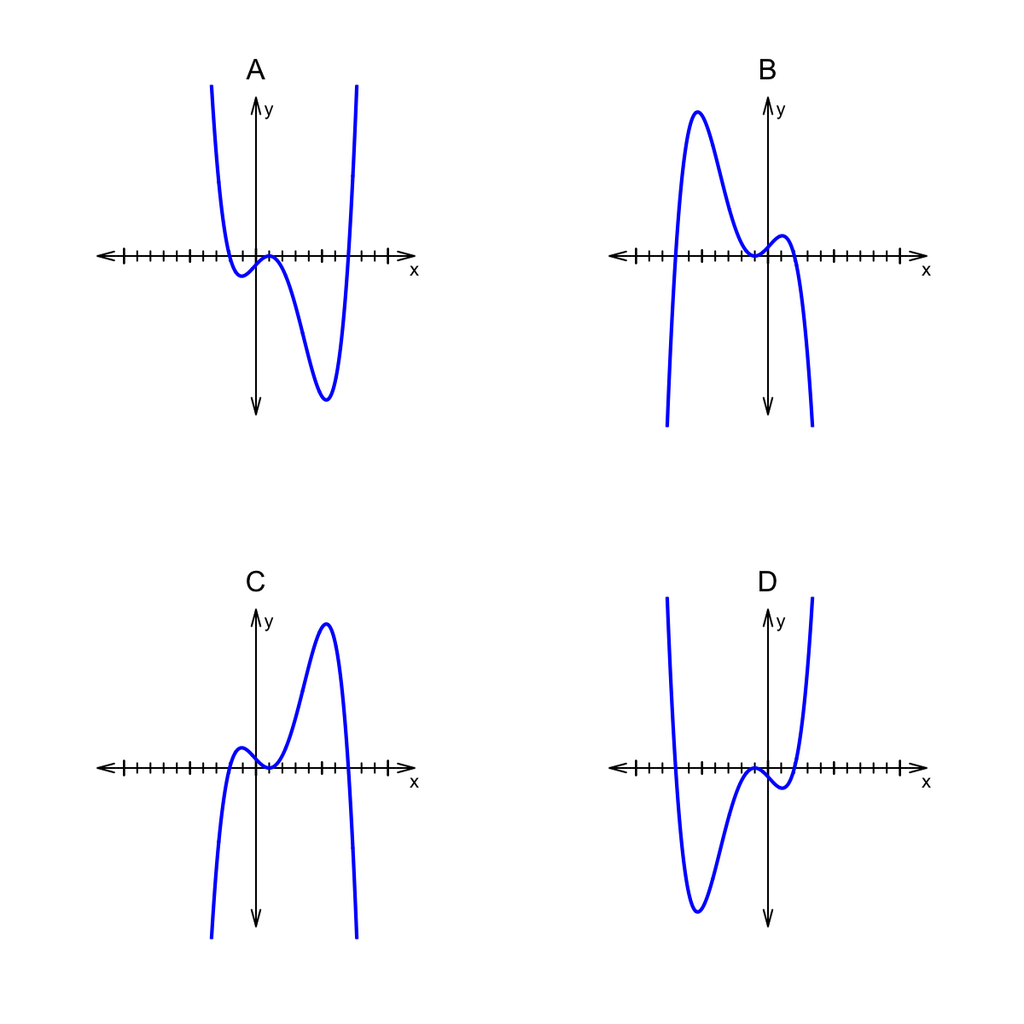

ABCD

First, consider the end behavior. If you expanded the polynomial into standard form, the highest-degree term would be $x^{4}$.

$$p(x)~=~x^{4}+\ldots$$

The highest degree term has a positive coefficient and an even degree, so the end behavior is **"up,up"**. Or, more formally, $\lim\limits_{x\to-\infty} p(x) ~=~ \infty$ and $\lim\limits_{x\to\infty} p(x) ~=~ \infty$.

Next, we consider the roots. From the factored form, $p(x)~=~(x+2)\cdot (x-1)^{2}\cdot (x-7)$, it is easy to see (see [zero-product property](https://en.wikipedia.org/wiki/Zero-product_property)) that $x=-2$ or $x=1$ or $x=7$ makes the polynomial output 0.

$$p(-2)~=~(-2+2)\cdot (-2-1)^{2}\cdot
(-2-7)~=~0$$
$$p(1)~=~(1+2)\cdot
(1-1)^{2}\cdot (1-7)~=~0$$
$$p(7)~=~(7+2)\cdot (7-1)^{2}\cdot
(7-7)~=~0$$

We predict that at $x=1$ there is a double root (multiplicity of 2) because the corresponding factor is squared. Graphically, we expect the curve to "bounce" off the $x$ axis at $x=1$. At the other roots, we expect the curve to cut through the $x$ axis.

Anyway, based on this analysis, we can produce a [sign](https://en.wikipedia.org/wiki/Sign_function) graph of the polynomial.

| $x$ interval or value | sign analysis of $p(x)~=~(x+2)\cdot (x-1)^{2}\cdot (x-7)$ | sign |
| --- | --- | --- |
| $(-\infty,-2)$ | $(\mathrm{neg})\cdot (\mathrm{neg})^{2}\cdot (\mathrm{neg})$ | $1$ |
| $-2$ | $(\mathrm{zero})\cdot (\mathrm{neg})^{2}\cdot (\mathrm{neg})$ | $0$ |
| $(-2,1)$ | $(\mathrm{pos})\cdot (\mathrm{neg})^{2}\cdot (\mathrm{neg})$ | $-1$ |
| $1$ | $(\mathrm{pos})\cdot (\mathrm{zero})^{2}\cdot (\mathrm{neg})$ | $0$ |
| $(1,7)$ | $(\mathrm{pos})\cdot (\mathrm{pos})^{2}\cdot (\mathrm{neg})$ | $-1$ |
| $7$ | $(\mathrm{pos})\cdot (\mathrm{pos})^{2}\cdot (\mathrm{zero})$ | $0$ |
| $(7,\infty)$ | $(\mathrm{pos})\cdot (\mathrm{pos})^{2}\cdot (\mathrm{pos})$ | $1$ |

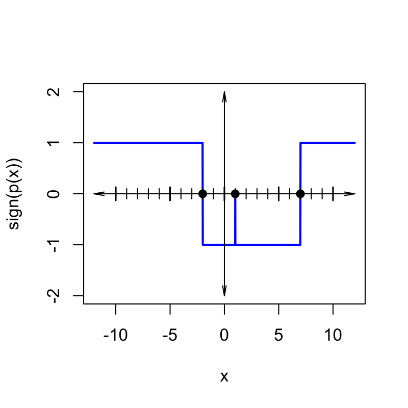

And only one option matches.

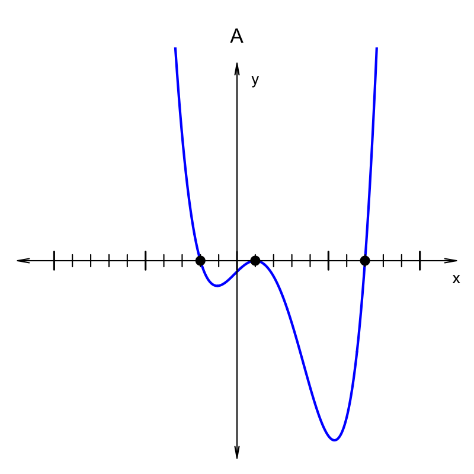

A polynomial, $p(x)$, is given in factored form.
$$p(x)~=~-(x+9)^{2}\cdot
(x-6)$$

Which of the following graphs matches $y=p(x)$?

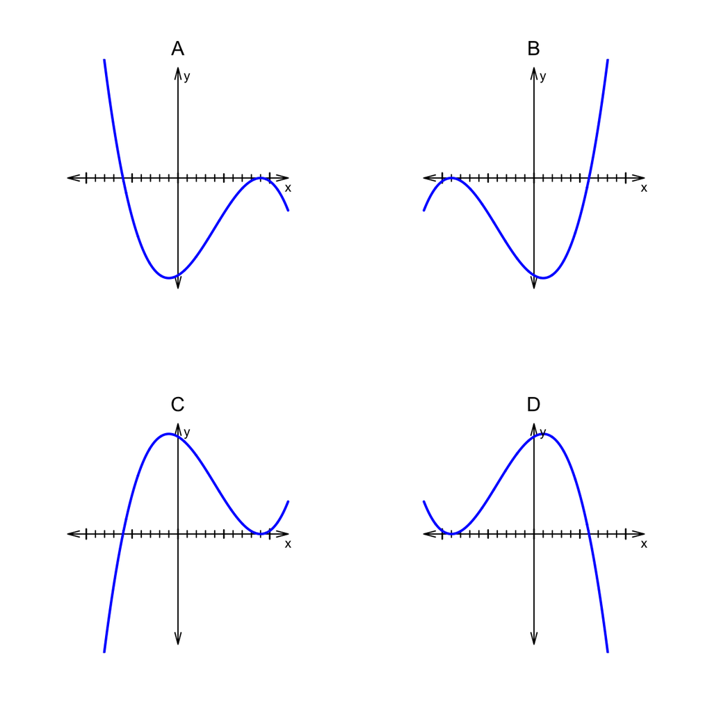

ABCD

First, consider the end behavior. If you expanded the polynomial into standard form, the highest-degree term would be $-x^{3}$.

$$p(x)~=~-x^{3}+\ldots$$

The highest degree term has a negative coefficient and an odd degree, so the end behavior is **"up,down"**. Or, more formally, $\lim\limits_{x\to-\infty} p(x) ~=~ \infty$ and $\lim\limits_{x\to\infty} p(x) ~=~ -\infty$.

Next, we consider the roots. From the factored form, $p(x)~=~-(x+9)^{2}\cdot (x-6)$, it is easy to see (see [zero-product property](https://en.wikipedia.org/wiki/Zero-product_property)) that $x=-9$ or $x=6$ makes the polynomial output 0.

$$p(-9)~=~-(-9+9)^{2}\cdot
(-9-6)~=~0$$
$$p(6)~=~-(6+9)^{2}\cdot
(6-6)~=~0$$

We predict that at $x=-9$ there is a double root (multiplicity of 2) because the corresponding factor is squared. Graphically, we expect the curve to "bounce" off the $x$ axis at $x=-9$. At the other root, we expect the curve to cut through the $x$ axis.

Anyway, based on this analysis, we can produce a [sign](https://en.wikipedia.org/wiki/Sign_function) graph of the polynomial.

| $x$ interval or value | sign analysis of $p(x)~=~-(x+9)^{2}\cdot (x-6)$ | sign |
| --- | --- | --- |
| $(-\infty,-9)$ | $-(\mathrm{neg})^{2}\cdot (\mathrm{neg})$ | $1$ |
| $-9$ | $-(\mathrm{zero})^{2}\cdot (\mathrm{neg})$ | $0$ |
| $(-9,6)$ | $-(\mathrm{pos})^{2}\cdot (\mathrm{neg})$ | $1$ |
| $6$ | $-(\mathrm{pos})^{2}\cdot (\mathrm{zero})$ | $0$ |
| $(6,\infty)$ | $-(\mathrm{pos})^{2}\cdot (\mathrm{pos})$ | $-1$ |

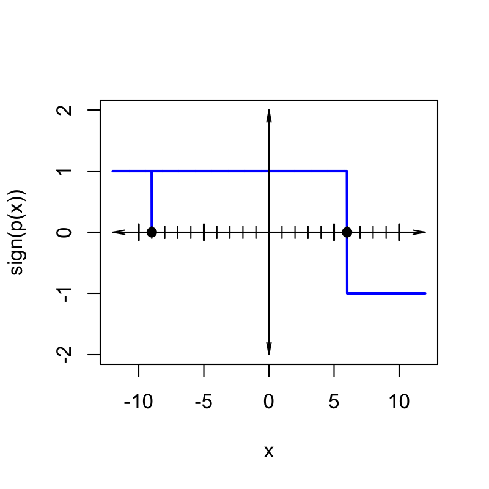

And only one option matches.

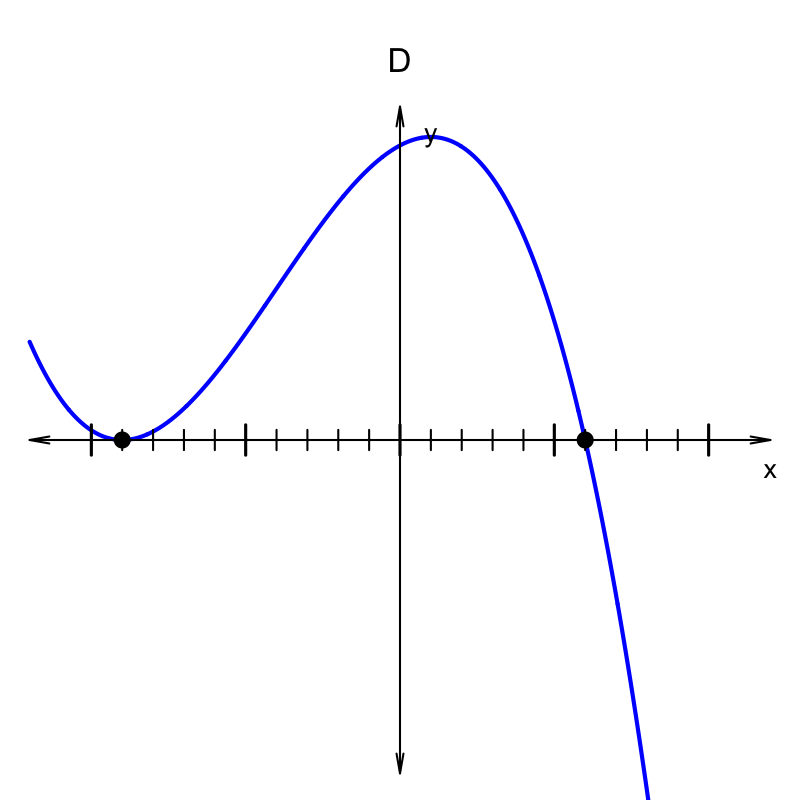

A polynomial, $p(x)$, is given in factored form.
$$p(x)~=~-(x+3)\cdot
(x-5)^{2}\cdot (x-9)$$

Which of the following graphs matches $y=p(x)$?

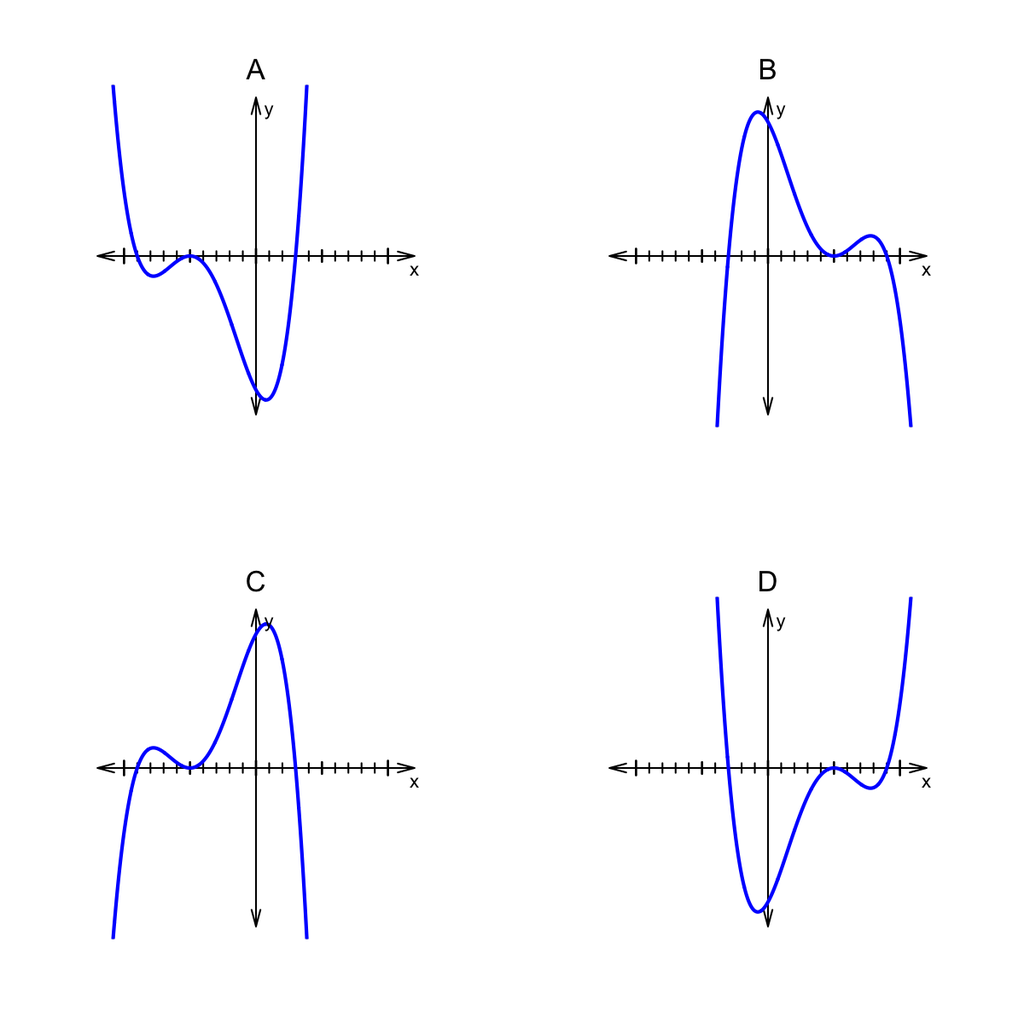

ABCD

First, consider the end behavior. If you expanded the polynomial into standard form, the highest-degree term would be $-x^{4}$.

$$p(x)~=~-x^{4}+\ldots$$

The highest degree term has a negative coefficient and an even degree, so the end behavior is **"down,down"**. Or, more formally, $\lim\limits_{x\to-\infty} p(x) ~=~ -\infty$ and $\lim\limits_{x\to\infty} p(x) ~=~ -\infty$.

Next, we consider the roots. From the factored form, $p(x)~=~-(x+3)\cdot (x-5)^{2}\cdot (x-9)$, it is easy to see (see [zero-product property](https://en.wikipedia.org/wiki/Zero-product_property)) that $x=-3$ or $x=5$ or $x=9$ makes the polynomial output 0.

$$p(-3)~=~-(-3+3)\cdot (-3-5)^{2}\cdot
(-3-9)~=~0$$
$$p(5)~=~-(5+3)\cdot
(5-5)^{2}\cdot (5-9)~=~0$$
$$p(9)~=~-(9+3)\cdot (9-5)^{2}\cdot
(9-9)~=~0$$

We predict that at $x=5$ there is a double root (multiplicity of 2) because the corresponding factor is squared. Graphically, we expect the curve to "bounce" off the $x$ axis at $x=5$. At the other roots, we expect the curve to cut through the $x$ axis.

Anyway, based on this analysis, we can produce a [sign](https://en.wikipedia.org/wiki/Sign_function) graph of the polynomial.

| $x$ interval or value | sign analysis of $p(x)~=~-(x+3)\cdot (x-5)^{2}\cdot (x-9)$ | sign |
| --- | --- | --- |
| $(-\infty,-3)$ | $-(\mathrm{neg})\cdot (\mathrm{neg})^{2}\cdot (\mathrm{neg})$ | $-1$ |
| $-3$ | $-(\mathrm{zero})\cdot (\mathrm{neg})^{2}\cdot (\mathrm{neg})$ | $0$ |
| $(-3,5)$ | $-(\mathrm{pos})\cdot (\mathrm{neg})^{2}\cdot (\mathrm{neg})$ | $1$ |
| $5$ | $-(\mathrm{pos})\cdot (\mathrm{zero})^{2}\cdot (\mathrm{neg})$ | $0$ |
| $(5,9)$ | $-(\mathrm{pos})\cdot (\mathrm{pos})^{2}\cdot (\mathrm{neg})$ | $1$ |
| $9$ | $-(\mathrm{pos})\cdot (\mathrm{pos})^{2}\cdot (\mathrm{zero})$ | $0$ |
| $(9,\infty)$ | $-(\mathrm{pos})\cdot (\mathrm{pos})^{2}\cdot (\mathrm{pos})$ | $-1$ |

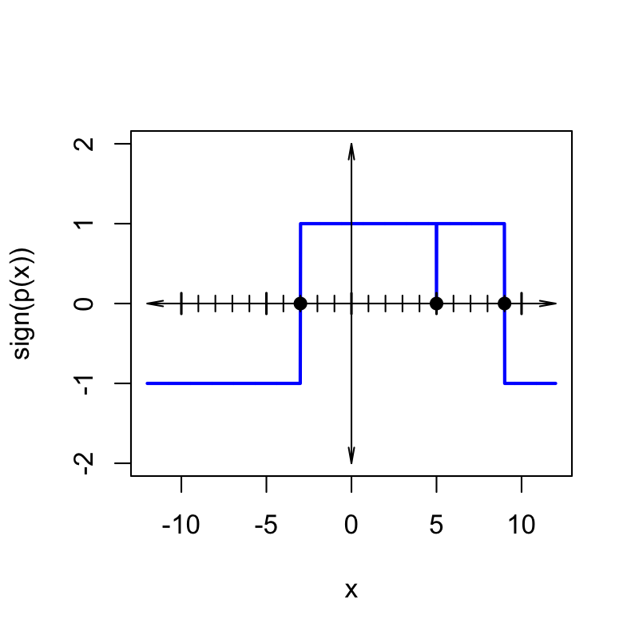

And only one option matches.

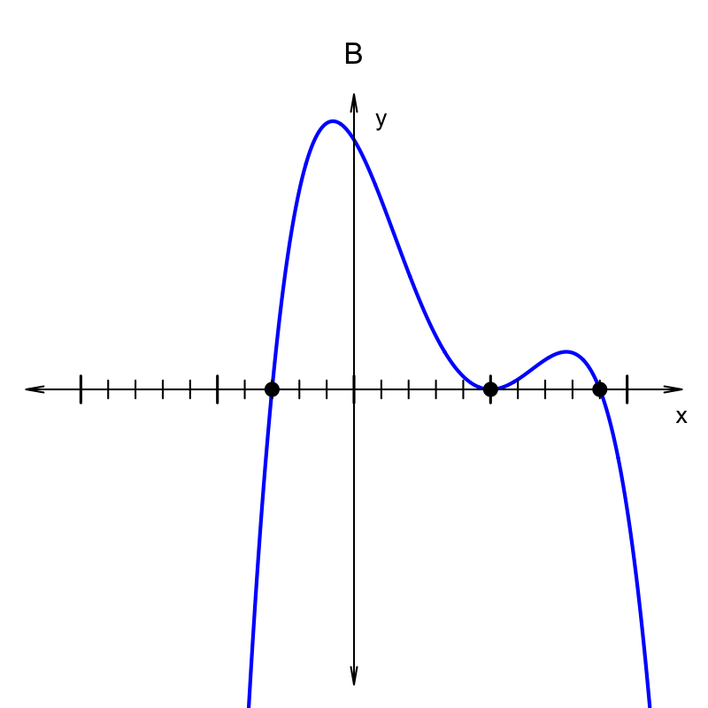

A polynomial, $p(x)$, is given in factored form.
$$p(x)~=~-(x+6)^{2}\cdot
(x-4)$$

Which of the following graphs matches $y=p(x)$?

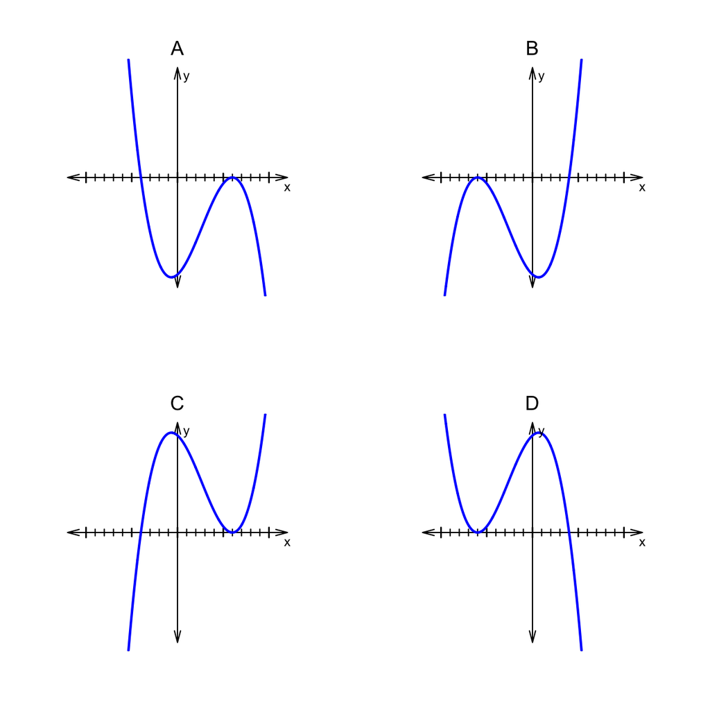

ABCD

First, consider the end behavior. If you expanded the polynomial into standard form, the highest-degree term would be $-x^{3}$.

$$p(x)~=~-x^{3}+\ldots$$

The highest degree term has a negative coefficient and an odd degree, so the end behavior is **"up,down"**. Or, more formally, $\lim\limits_{x\to-\infty} p(x) ~=~ \infty$ and $\lim\limits_{x\to\infty} p(x) ~=~ -\infty$.

Next, we consider the roots. From the factored form, $p(x)~=~-(x+6)^{2}\cdot (x-4)$, it is easy to see (see [zero-product property](https://en.wikipedia.org/wiki/Zero-product_property)) that $x=-6$ or $x=4$ makes the polynomial output 0.

$$p(-6)~=~-(-6+6)^{2}\cdot
(-6-4)~=~0$$
$$p(4)~=~-(4+6)^{2}\cdot
(4-4)~=~0$$

We predict that at $x=-6$ there is a double root (multiplicity of 2) because the corresponding factor is squared. Graphically, we expect the curve to "bounce" off the $x$ axis at $x=-6$. At the other root, we expect the curve to cut through the $x$ axis.

Anyway, based on this analysis, we can produce a [sign](https://en.wikipedia.org/wiki/Sign_function) graph of the polynomial.

| $x$ interval or value | sign analysis of $p(x)~=~-(x+6)^{2}\cdot (x-4)$ | sign |
| --- | --- | --- |
| $(-\infty,-6)$ | $-(\mathrm{neg})^{2}\cdot (\mathrm{neg})$ | $1$ |
| $-6$ | $-(\mathrm{zero})^{2}\cdot (\mathrm{neg})$ | $0$ |
| $(-6,4)$ | $-(\mathrm{pos})^{2}\cdot (\mathrm{neg})$ | $1$ |
| $4$ | $-(\mathrm{pos})^{2}\cdot (\mathrm{zero})$ | $0$ |
| $(4,\infty)$ | $-(\mathrm{pos})^{2}\cdot (\mathrm{pos})$ | $-1$ |

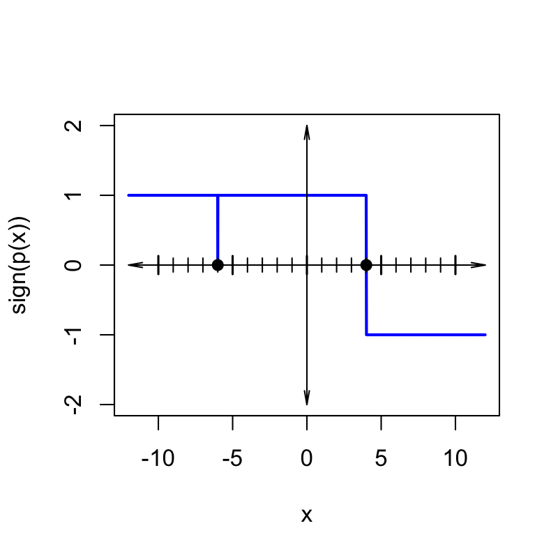

And only one option matches.

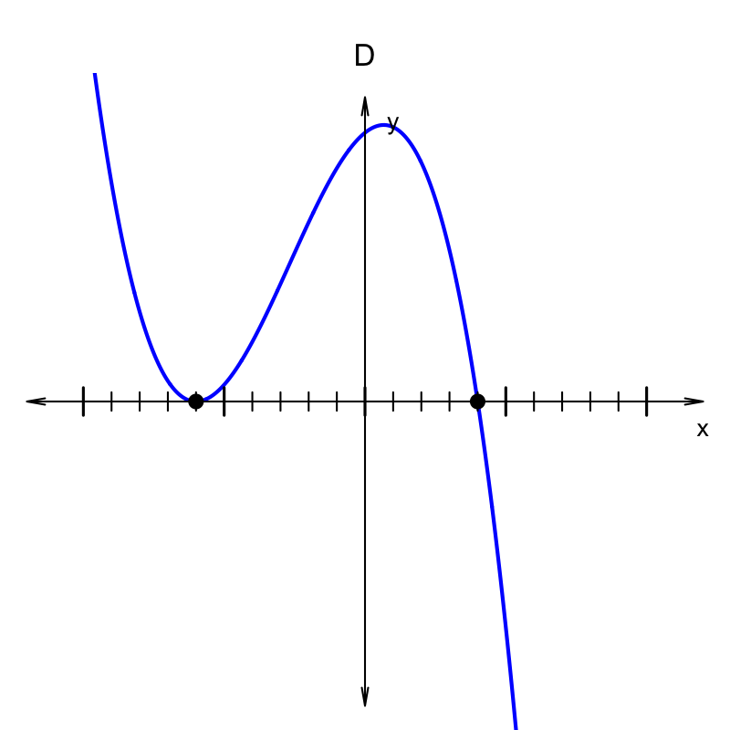

A polynomial, $p(x)$, is given in factored form.
$$p(x)~=~-(x+9)^{2}\cdot
(x-1)$$

Which of the following graphs matches $y=p(x)$?

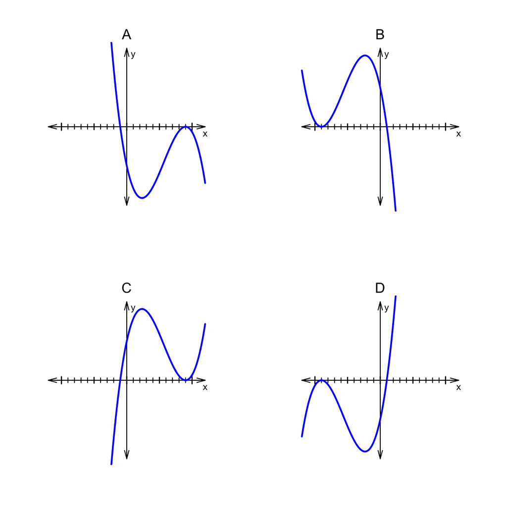

ABCD

First, consider the end behavior. If you expanded the polynomial into standard form, the highest-degree term would be $-x^{3}$.

$$p(x)~=~-x^{3}+\ldots$$

The highest degree term has a negative coefficient and an odd degree, so the end behavior is **"up,down"**. Or, more formally, $\lim\limits_{x\to-\infty} p(x) ~=~ \infty$ and $\lim\limits_{x\to\infty} p(x) ~=~ -\infty$.

Next, we consider the roots. From the factored form, $p(x)~=~-(x+9)^{2}\cdot (x-1)$, it is easy to see (see [zero-product property](https://en.wikipedia.org/wiki/Zero-product_property)) that $x=-9$ or $x=1$ makes the polynomial output 0.

$$p(-9)~=~-(-9+9)^{2}\cdot
(-9-1)~=~0$$
$$p(1)~=~-(1+9)^{2}\cdot
(1-1)~=~0$$

We predict that at $x=-9$ there is a double root (multiplicity of 2) because the corresponding factor is squared. Graphically, we expect the curve to "bounce" off the $x$ axis at $x=-9$. At the other root, we expect the curve to cut through the $x$ axis.

Anyway, based on this analysis, we can produce a [sign](https://en.wikipedia.org/wiki/Sign_function) graph of the polynomial.

| $x$ interval or value | sign analysis of $p(x)~=~-(x+9)^{2}\cdot (x-1)$ | sign |
| --- | --- | --- |
| $(-\infty,-9)$ | $-(\mathrm{neg})^{2}\cdot (\mathrm{neg})$ | $1$ |
| $-9$ | $-(\mathrm{zero})^{2}\cdot (\mathrm{neg})$ | $0$ |
| $(-9,1)$ | $-(\mathrm{pos})^{2}\cdot (\mathrm{neg})$ | $1$ |
| $1$ | $-(\mathrm{pos})^{2}\cdot (\mathrm{zero})$ | $0$ |
| $(1,\infty)$ | $-(\mathrm{pos})^{2}\cdot (\mathrm{pos})$ | $-1$ |

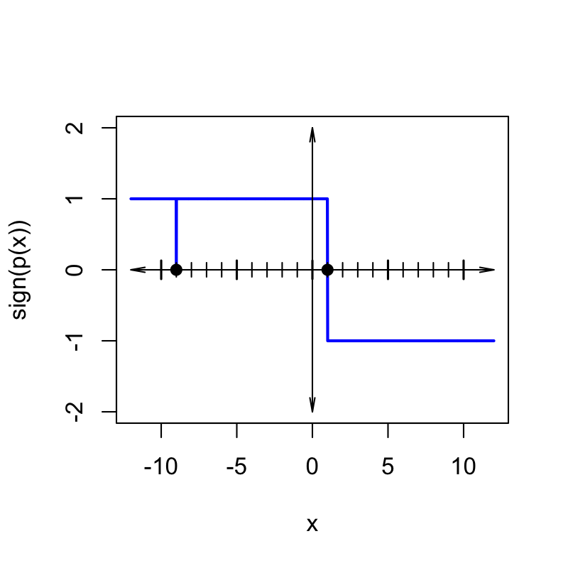

And only one option matches.

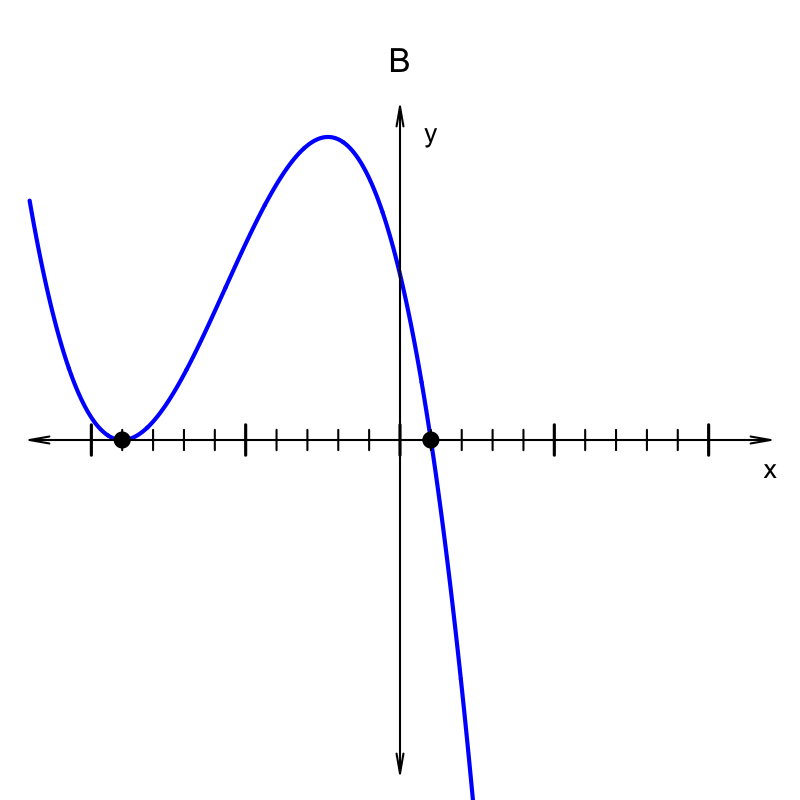

A polynomial, $p(x)$, is given in factored form.
$$p(x)~=~-(x+4)^{2}\cdot
(x-2)\cdot (x-7)$$

Which of the following graphs matches $y=p(x)$?

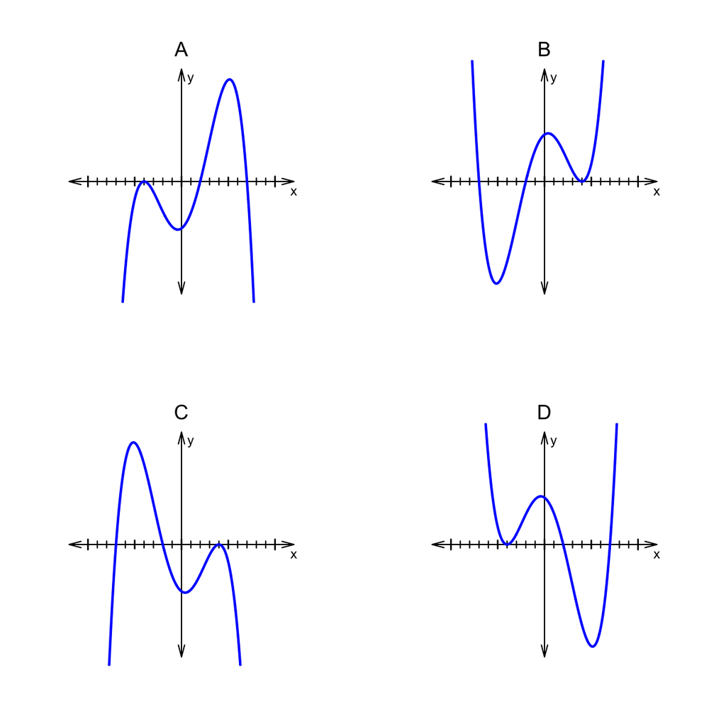

ABCD

First, consider the end behavior. If you expanded the polynomial into standard form, the highest-degree term would be $-x^{4}$.

$$p(x)~=~-x^{4}+\ldots$$

The highest degree term has a negative coefficient and an even degree, so the end behavior is **"down,down"**. Or, more formally, $\lim\limits_{x\to-\infty} p(x) ~=~ -\infty$ and $\lim\limits_{x\to\infty} p(x) ~=~ -\infty$.

Next, we consider the roots. From the factored form, $p(x)~=~-(x+4)^{2}\cdot (x-2)\cdot (x-7)$, it is easy to see (see [zero-product property](https://en.wikipedia.org/wiki/Zero-product_property)) that $x=-4$ or $x=2$ or $x=7$ makes the polynomial output 0.

$$p(-4)~=~-(-4+4)^{2}\cdot (-4-2)\cdot
(-4-7)~=~0$$
$$p(2)~=~-(2+4)^{2}\cdot
(2-2)\cdot (2-7)~=~0$$
$$p(7)~=~-(7+4)^{2}\cdot (7-2)\cdot
(7-7)~=~0$$

We predict that at $x=-4$ there is a double root (multiplicity of 2) because the corresponding factor is squared. Graphically, we expect the curve to "bounce" off the $x$ axis at $x=-4$. At the other roots, we expect the curve to cut through the $x$ axis.

Anyway, based on this analysis, we can produce a [sign](https://en.wikipedia.org/wiki/Sign_function) graph of the polynomial.

| $x$ interval or value | sign analysis of $p(x)~=~-(x+4)^{2}\cdot (x-2)\cdot (x-7)$ | sign |
| --- | --- | --- |
| $(-\infty,-4)$ | $-(\mathrm{neg})^{2}\cdot (\mathrm{neg})\cdot (\mathrm{neg})$ | $-1$ |
| $-4$ | $-(\mathrm{zero})^{2}\cdot (\mathrm{neg})\cdot (\mathrm{neg})$ | $0$ |
| $(-4,2)$ | $-(\mathrm{pos})^{2}\cdot (\mathrm{neg})\cdot (\mathrm{neg})$ | $-1$ |
| $2$ | $-(\mathrm{pos})^{2}\cdot (\mathrm{zero})\cdot (\mathrm{neg})$ | $0$ |
| $(2,7)$ | $-(\mathrm{pos})^{2}\cdot (\mathrm{pos})\cdot (\mathrm{neg})$ | $1$ |
| $7$ | $-(\mathrm{pos})^{2}\cdot (\mathrm{pos})\cdot (\mathrm{zero})$ | $0$ |
| $(7,\infty)$ | $-(\mathrm{pos})^{2}\cdot (\mathrm{pos})\cdot (\mathrm{pos})$ | $-1$ |

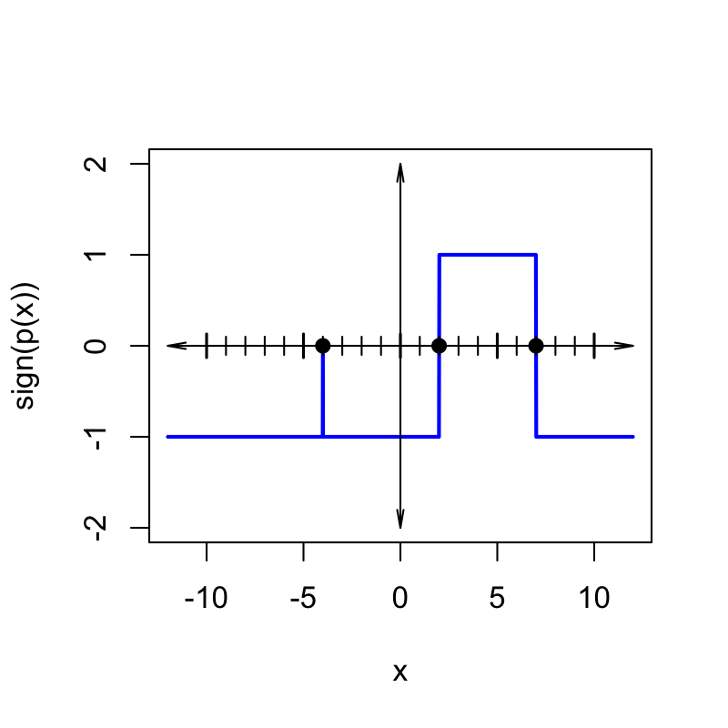

And only one option matches.

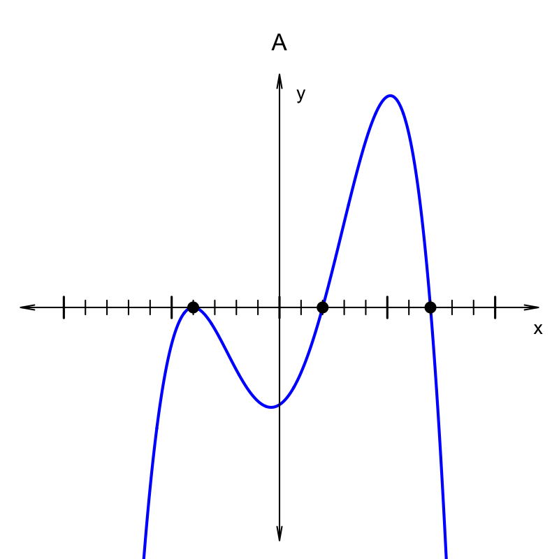

A polynomial, $p(x)$, is given in factored form.
$$p(x)~=~(x+8)^{2}\cdot
(x-9)$$

Which of the following graphs matches $y=p(x)$?

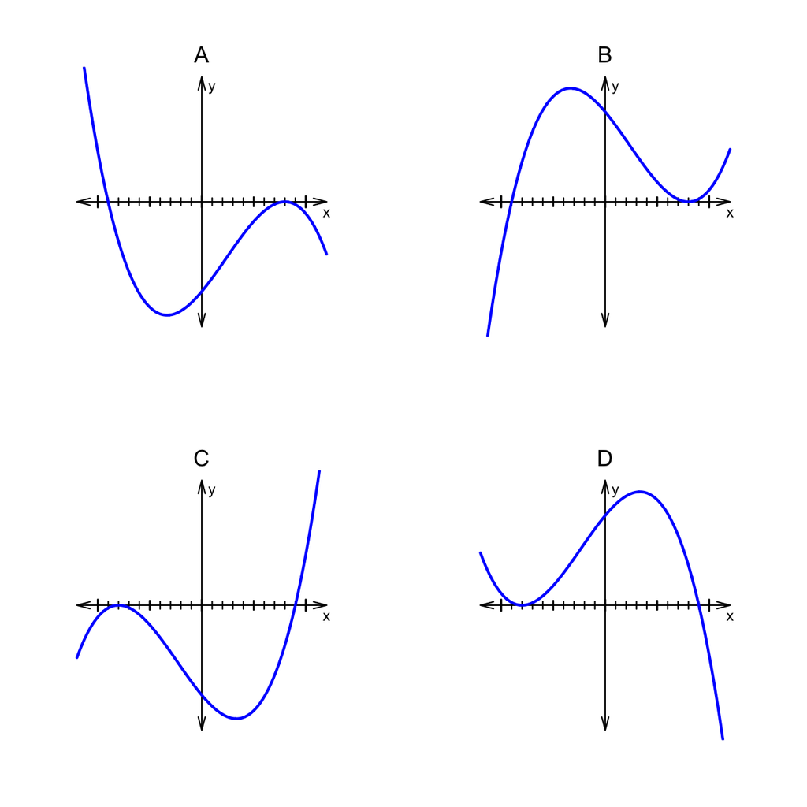

ABCD

First, consider the end behavior. If you expanded the polynomial into standard form, the highest-degree term would be $x^{3}$.

$$p(x)~=~x^{3}+\ldots$$

The highest degree term has a positive coefficient and an odd degree, so the end behavior is **"down,up"**. Or, more formally, $\lim\limits_{x\to-\infty} p(x) ~=~ -\infty$ and $\lim\limits_{x\to\infty} p(x) ~=~ \infty$.

Next, we consider the roots. From the factored form, $p(x)~=~(x+8)^{2}\cdot (x-9)$, it is easy to see (see [zero-product property](https://en.wikipedia.org/wiki/Zero-product_property)) that $x=-8$ or $x=9$ makes the polynomial output 0.

$$p(-8)~=~(-8+8)^{2}\cdot
(-8-9)~=~0$$
$$p(9)~=~(9+8)^{2}\cdot
(9-9)~=~0$$

We predict that at $x=-8$ there is a double root (multiplicity of 2) because the corresponding factor is squared. Graphically, we expect the curve to "bounce" off the $x$ axis at $x=-8$. At the other root, we expect the curve to cut through the $x$ axis.

Anyway, based on this analysis, we can produce a [sign](https://en.wikipedia.org/wiki/Sign_function) graph of the polynomial.

| $x$ interval or value | sign analysis of $p(x)~=~(x+8)^{2}\cdot (x-9)$ | sign |
| --- | --- | --- |
| $(-\infty,-8)$ | $(\mathrm{neg})^{2}\cdot (\mathrm{neg})$ | $-1$ |
| $-8$ | $(\mathrm{zero})^{2}\cdot (\mathrm{neg})$ | $0$ |
| $(-8,9)$ | $(\mathrm{pos})^{2}\cdot (\mathrm{neg})$ | $-1$ |
| $9$ | $(\mathrm{pos})^{2}\cdot (\mathrm{zero})$ | $0$ |
| $(9,\infty)$ | $(\mathrm{pos})^{2}\cdot (\mathrm{pos})$ | $1$ |

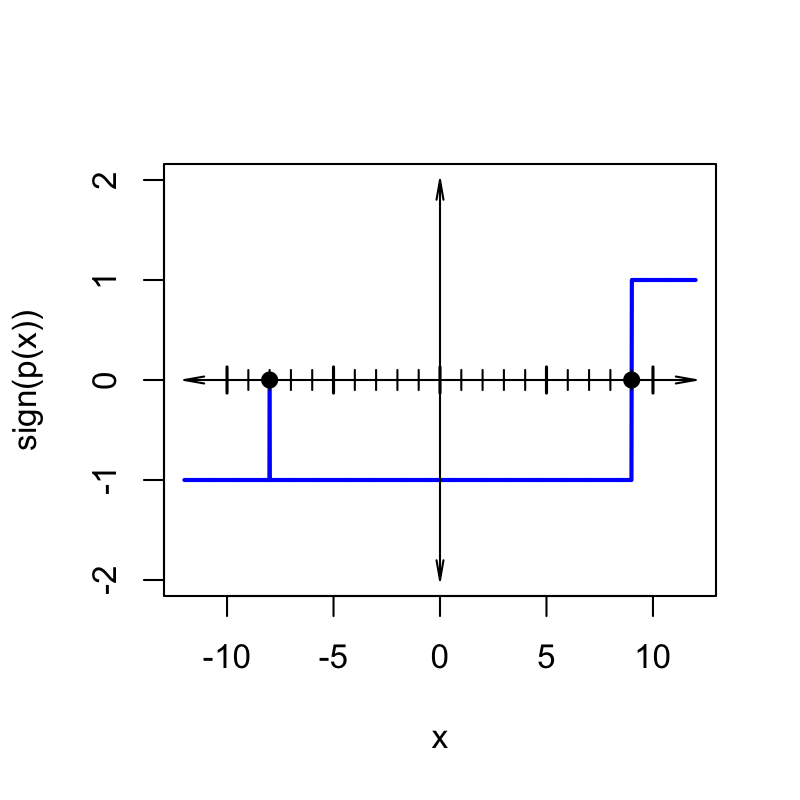

And only one option matches.

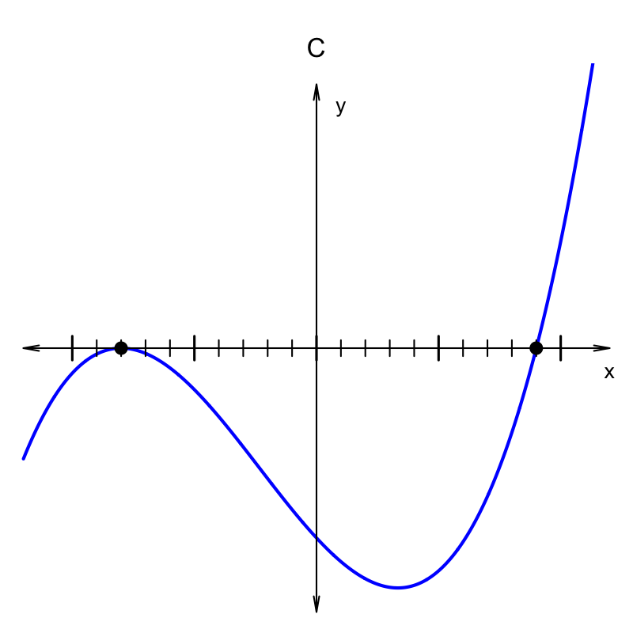

A polynomial, $p(x)$, is given in factored form.
$$p(x)~=~(x+1)\cdot (x-3)\cdot
(x-8)^{2}$$

Which of the following graphs matches $y=p(x)$?

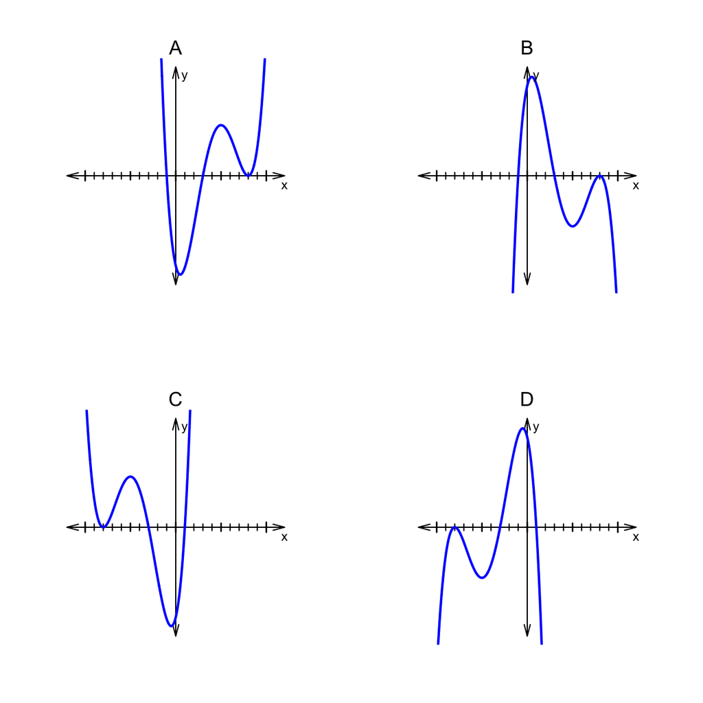

ABCD

First, consider the end behavior. If you expanded the polynomial into standard form, the highest-degree term would be $x^{4}$.

$$p(x)~=~x^{4}+\ldots$$

The highest degree term has a positive coefficient and an even degree, so the end behavior is **"up,up"**. Or, more formally, $\lim\limits_{x\to-\infty} p(x) ~=~ \infty$ and $\lim\limits_{x\to\infty} p(x) ~=~ \infty$.

Next, we consider the roots. From the factored form, $p(x)~=~(x+1)\cdot (x-3)\cdot (x-8)^{2}$, it is easy to see (see [zero-product property](https://en.wikipedia.org/wiki/Zero-product_property)) that $x=-1$ or $x=3$ or $x=8$ makes the polynomial output 0.

$$p(-1)~=~(-1+1)\cdot (-1-3)\cdot
(-1-8)^{2}~=~0$$
$$p(3)~=~(3+1)\cdot
(3-3)\cdot (3-8)^{2}~=~0$$
$$p(8)~=~(8+1)\cdot (8-3)\cdot
(8-8)^{2}~=~0$$

We predict that at $x=8$ there is a double root (multiplicity of 2) because the corresponding factor is squared. Graphically, we expect the curve to "bounce" off the $x$ axis at $x=8$. At the other roots, we expect the curve to cut through the $x$ axis.

Anyway, based on this analysis, we can produce a [sign](https://en.wikipedia.org/wiki/Sign_function) graph of the polynomial.

| $x$ interval or value | sign analysis of $p(x)~=~(x+1)\cdot (x-3)\cdot (x-8)^{2}$ | sign |
| --- | --- | --- |
| $(-\infty,-1)$ | $(\mathrm{neg})\cdot (\mathrm{neg})\cdot (\mathrm{neg})^{2}$ | $1$ |
| $-1$ | $(\mathrm{zero})\cdot (\mathrm{neg})\cdot (\mathrm{neg})^{2}$ | $0$ |
| $(-1,3)$ | $(\mathrm{pos})\cdot (\mathrm{neg})\cdot (\mathrm{neg})^{2}$ | $-1$ |
| $3$ | $(\mathrm{pos})\cdot (\mathrm{zero})\cdot (\mathrm{neg})^{2}$ | $0$ |
| $(3,8)$ | $(\mathrm{pos})\cdot (\mathrm{pos})\cdot (\mathrm{neg})^{2}$ | $1$ |
| $8$ | $(\mathrm{pos})\cdot (\mathrm{pos})\cdot (\mathrm{zero})^{2}$ | $0$ |
| $(8,\infty)$ | $(\mathrm{pos})\cdot (\mathrm{pos})\cdot (\mathrm{pos})^{2}$ | $1$ |

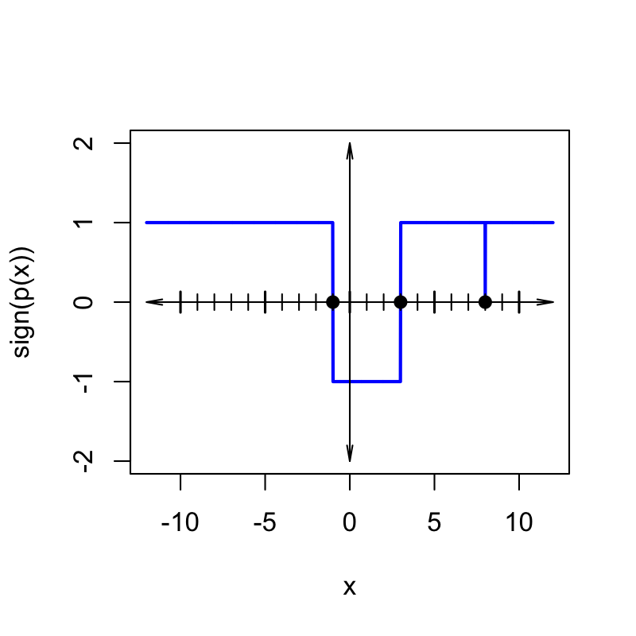

And only one option matches.

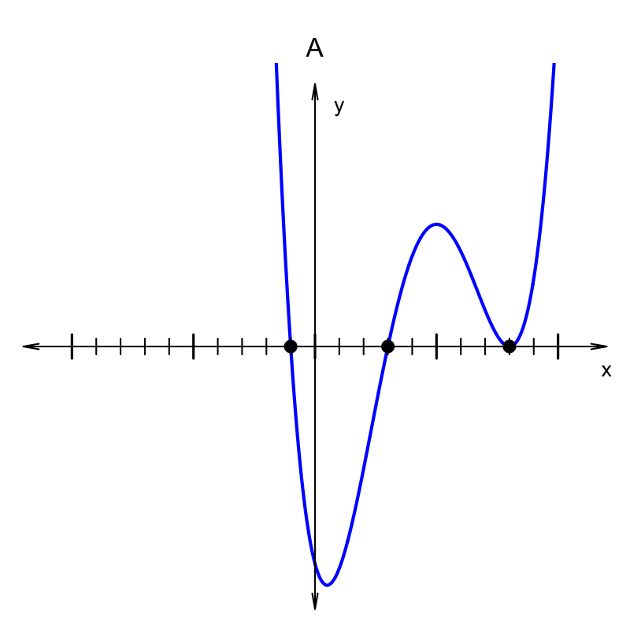

A polynomial, $p(x)$, is given in factored form.
$$p(x)~=~(x+5)\cdot (x-1)\cdot
(x-4)^{2}$$

Which of the following graphs matches $y=p(x)$?

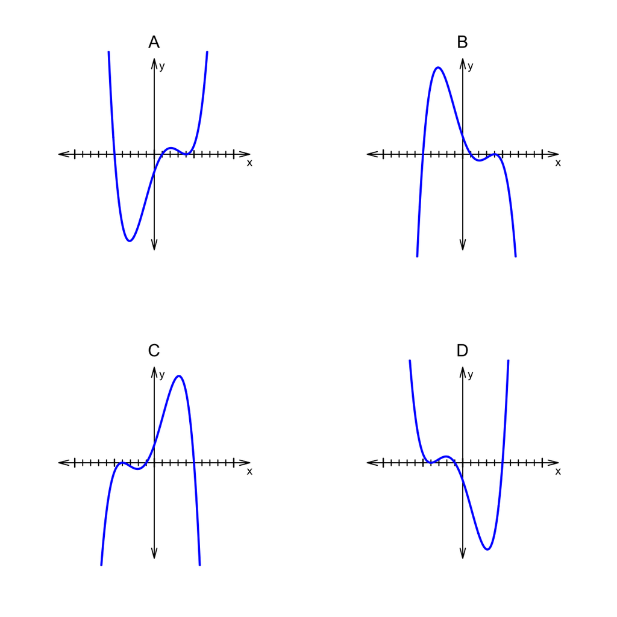

ABCD

First, consider the end behavior. If you expanded the polynomial into standard form, the highest-degree term would be $x^{4}$.

$$p(x)~=~x^{4}+\ldots$$

The highest degree term has a positive coefficient and an even degree, so the end behavior is **"up,up"**. Or, more formally, $\lim\limits_{x\to-\infty} p(x) ~=~ \infty$ and $\lim\limits_{x\to\infty} p(x) ~=~ \infty$.

Next, we consider the roots. From the factored form, $p(x)~=~(x+5)\cdot (x-1)\cdot (x-4)^{2}$, it is easy to see (see [zero-product property](https://en.wikipedia.org/wiki/Zero-product_property)) that $x=-5$ or $x=1$ or $x=4$ makes the polynomial output 0.

$$p(-5)~=~(-5+5)\cdot (-5-1)\cdot
(-5-4)^{2}~=~0$$
$$p(1)~=~(1+5)\cdot
(1-1)\cdot (1-4)^{2}~=~0$$
$$p(4)~=~(4+5)\cdot (4-1)\cdot
(4-4)^{2}~=~0$$

We predict that at $x=4$ there is a double root (multiplicity of 2) because the corresponding factor is squared. Graphically, we expect the curve to "bounce" off the $x$ axis at $x=4$. At the other roots, we expect the curve to cut through the $x$ axis.

Anyway, based on this analysis, we can produce a [sign](https://en.wikipedia.org/wiki/Sign_function) graph of the polynomial.

| $x$ interval or value | sign analysis of $p(x)~=~(x+5)\cdot (x-1)\cdot (x-4)^{2}$ | sign |
| --- | --- | --- |
| $(-\infty,-5)$ | $(\mathrm{neg})\cdot (\mathrm{neg})\cdot (\mathrm{neg})^{2}$ | $1$ |
| $-5$ | $(\mathrm{zero})\cdot (\mathrm{neg})\cdot (\mathrm{neg})^{2}$ | $0$ |
| $(-5,1)$ | $(\mathrm{pos})\cdot (\mathrm{neg})\cdot (\mathrm{neg})^{2}$ | $-1$ |
| $1$ | $(\mathrm{pos})\cdot (\mathrm{zero})\cdot (\mathrm{neg})^{2}$ | $0$ |
| $(1,4)$ | $(\mathrm{pos})\cdot (\mathrm{pos})\cdot (\mathrm{neg})^{2}$ | $1$ |
| $4$ | $(\mathrm{pos})\cdot (\mathrm{pos})\cdot (\mathrm{zero})^{2}$ | $0$ |
| $(4,\infty)$ | $(\mathrm{pos})\cdot (\mathrm{pos})\cdot (\mathrm{pos})^{2}$ | $1$ |

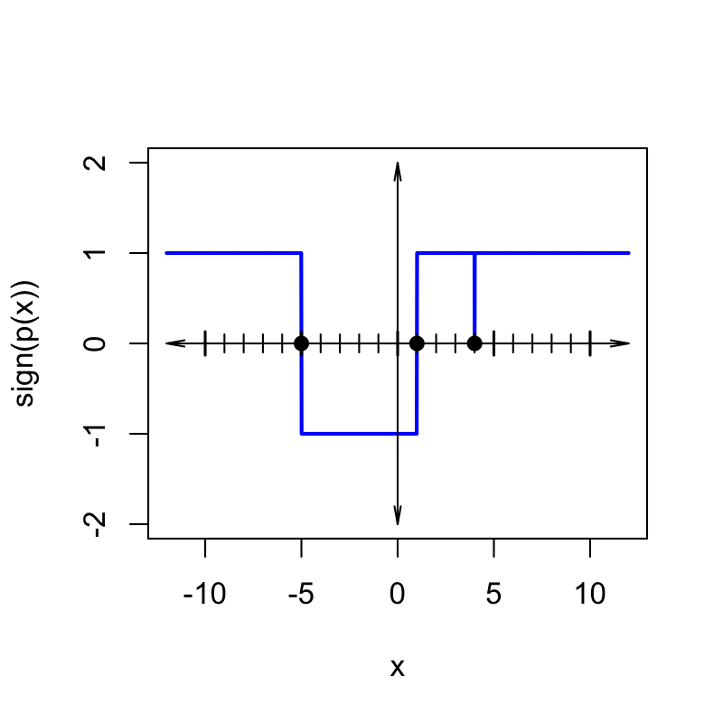

And only one option matches.

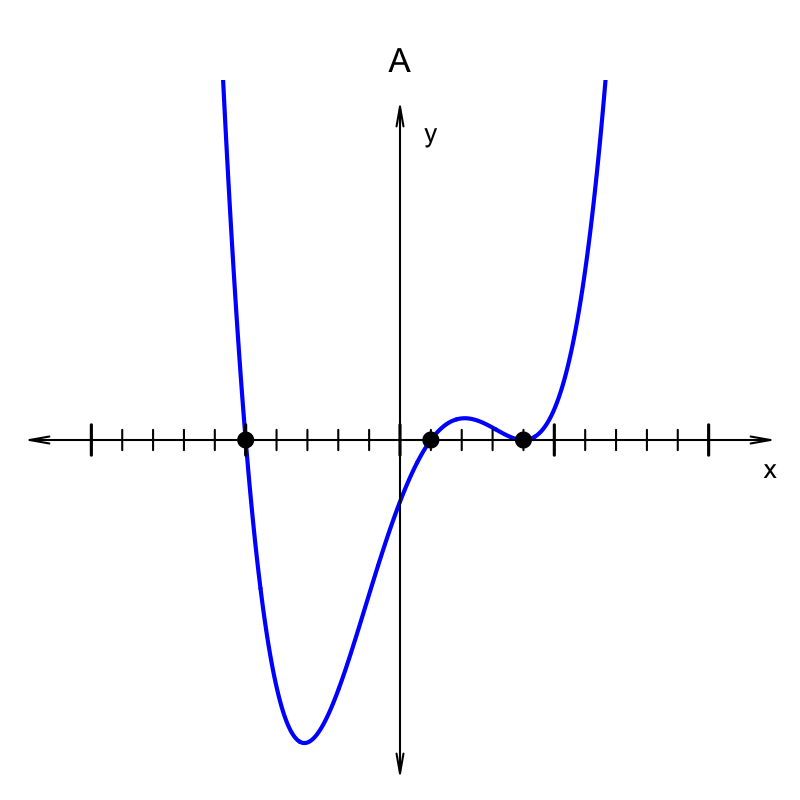

A polynomial, $p(x)$, is given in factored form.
$$p(x)~=~-(x+8)^{2}\cdot
(x-9)$$

Which of the following graphs matches $y=p(x)$?

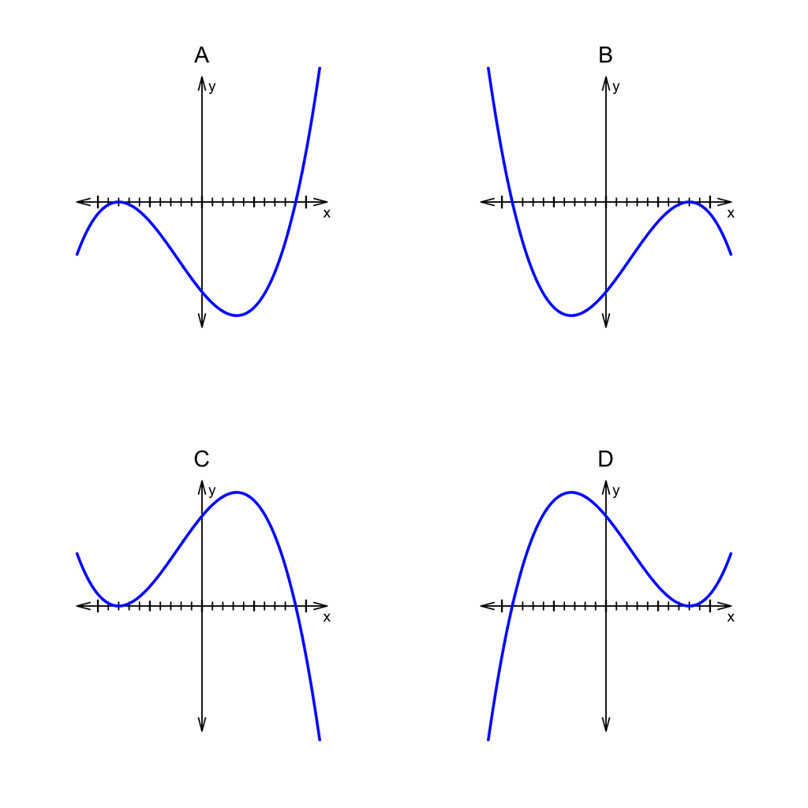

ABCD

First, consider the end behavior. If you expanded the polynomial into standard form, the highest-degree term would be $-x^{3}$.

$$p(x)~=~-x^{3}+\ldots$$

The highest degree term has a negative coefficient and an odd degree, so the end behavior is **"up,down"**. Or, more formally, $\lim\limits_{x\to-\infty} p(x) ~=~ \infty$ and $\lim\limits_{x\to\infty} p(x) ~=~ -\infty$.

Next, we consider the roots. From the factored form, $p(x)~=~-(x+8)^{2}\cdot (x-9)$, it is easy to see (see [zero-product property](https://en.wikipedia.org/wiki/Zero-product_property)) that $x=-8$ or $x=9$ makes the polynomial output 0.

$$p(-8)~=~-(-8+8)^{2}\cdot
(-8-9)~=~0$$
$$p(9)~=~-(9+8)^{2}\cdot
(9-9)~=~0$$

We predict that at $x=-8$ there is a double root (multiplicity of 2) because the corresponding factor is squared. Graphically, we expect the curve to "bounce" off the $x$ axis at $x=-8$. At the other root, we expect the curve to cut through the $x$ axis.

Anyway, based on this analysis, we can produce a [sign](https://en.wikipedia.org/wiki/Sign_function) graph of the polynomial.

| $x$ interval or value | sign analysis of $p(x)~=~-(x+8)^{2}\cdot (x-9)$ | sign |
| --- | --- | --- |
| $(-\infty,-8)$ | $-(\mathrm{neg})^{2}\cdot (\mathrm{neg})$ | $1$ |
| $-8$ | $-(\mathrm{zero})^{2}\cdot (\mathrm{neg})$ | $0$ |
| $(-8,9)$ | $-(\mathrm{pos})^{2}\cdot (\mathrm{neg})$ | $1$ |
| $9$ | $-(\mathrm{pos})^{2}\cdot (\mathrm{zero})$ | $0$ |
| $(9,\infty)$ | $-(\mathrm{pos})^{2}\cdot (\mathrm{pos})$ | $-1$ |

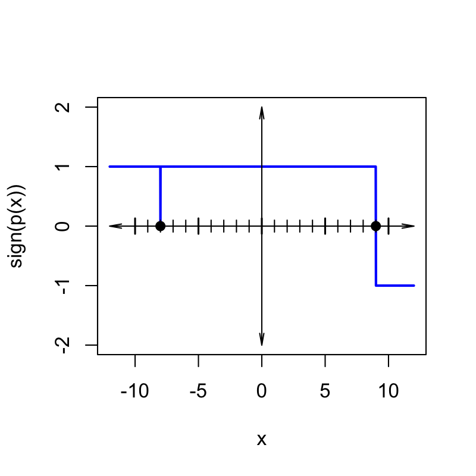

And only one option matches.

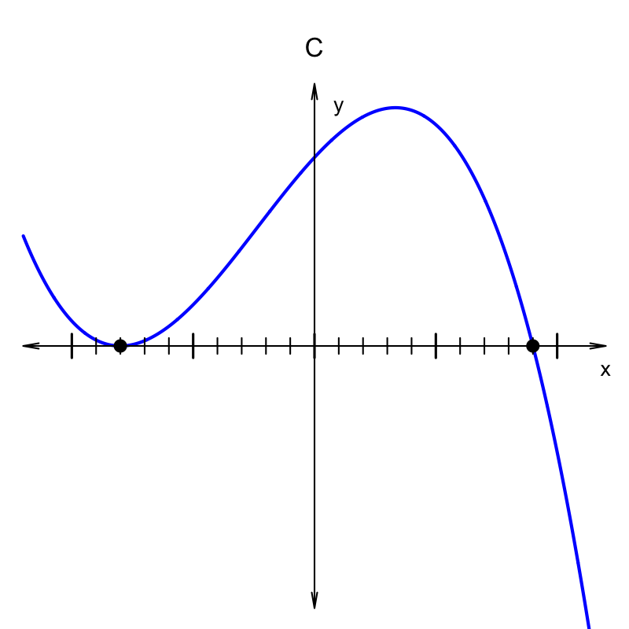

A polynomial, $p(x)$, is given in factored form.
$$p(x)~=~(x-3)\cdot
(x-6)^{2}\cdot (x-9)$$

Which of the following graphs matches $y=p(x)$?

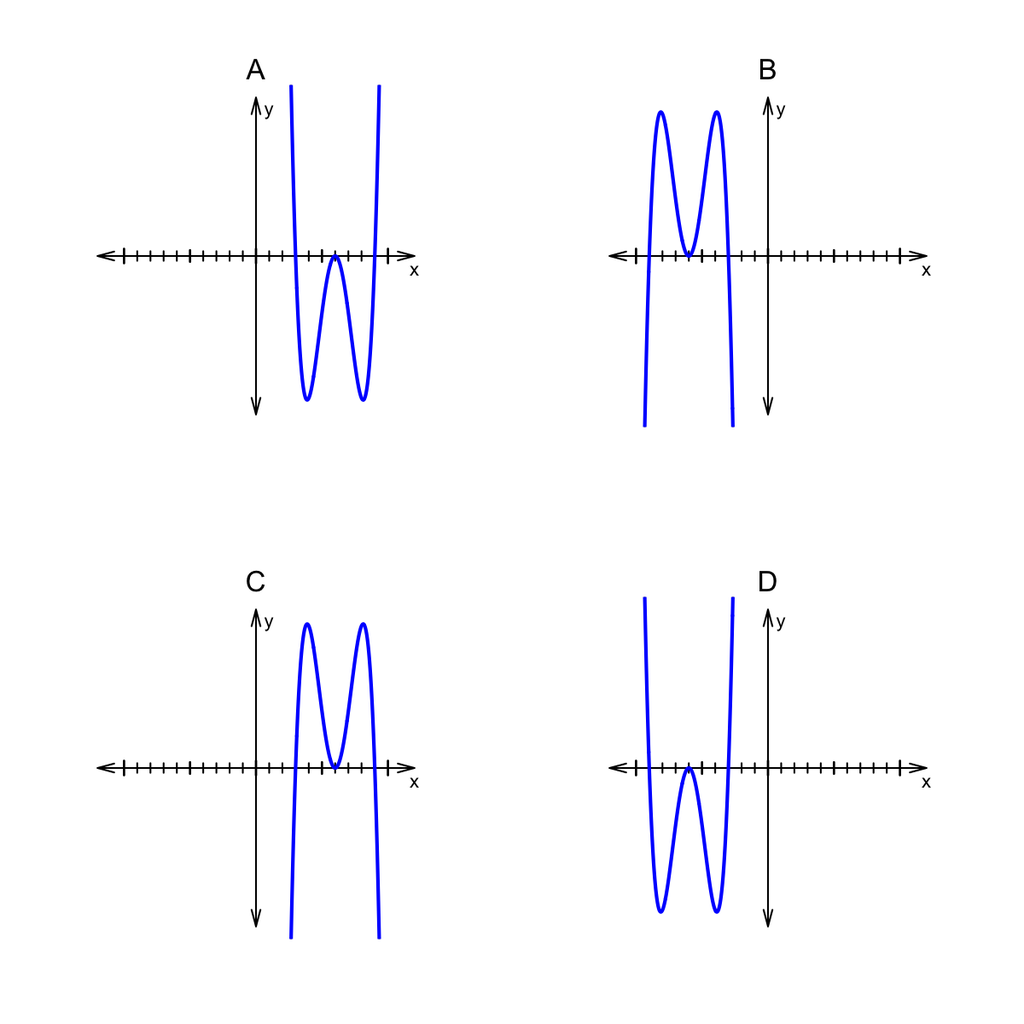

ABCD

First, consider the end behavior. If you expanded the polynomial into standard form, the highest-degree term would be $x^{4}$.

$$p(x)~=~x^{4}+\ldots$$

The highest degree term has a positive coefficient and an even degree, so the end behavior is **"up,up"**. Or, more formally, $\lim\limits_{x\to-\infty} p(x) ~=~ \infty$ and $\lim\limits_{x\to\infty} p(x) ~=~ \infty$.

Next, we consider the roots. From the factored form, $p(x)~=~(x-3)\cdot (x-6)^{2}\cdot (x-9)$, it is easy to see (see [zero-product property](https://en.wikipedia.org/wiki/Zero-product_property)) that $x=3$ or $x=6$ or $x=9$ makes the polynomial output 0.

$$p(3)~=~(3-3)\cdot (3-6)^{2}\cdot
(3-9)~=~0$$
$$p(6)~=~(6-3)\cdot
(6-6)^{2}\cdot (6-9)~=~0$$
$$p(9)~=~(9-3)\cdot (9-6)^{2}\cdot
(9-9)~=~0$$

We predict that at $x=6$ there is a double root (multiplicity of 2) because the corresponding factor is squared. Graphically, we expect the curve to "bounce" off the $x$ axis at $x=6$. At the other roots, we expect the curve to cut through the $x$ axis.

Anyway, based on this analysis, we can produce a [sign](https://en.wikipedia.org/wiki/Sign_function) graph of the polynomial.

| $x$ interval or value | sign analysis of $p(x)~=~(x-3)\cdot (x-6)^{2}\cdot (x-9)$ | sign |
| --- | --- | --- |
| $(-\infty,3)$ | $(\mathrm{neg})\cdot (\mathrm{neg})^{2}\cdot (\mathrm{neg})$ | $1$ |
| $3$ | $(\mathrm{zero})\cdot (\mathrm{neg})^{2}\cdot (\mathrm{neg})$ | $0$ |
| $(3,6)$ | $(\mathrm{pos})\cdot (\mathrm{neg})^{2}\cdot (\mathrm{neg})$ | $-1$ |
| $6$ | $(\mathrm{pos})\cdot (\mathrm{zero})^{2}\cdot (\mathrm{neg})$ | $0$ |
| $(6,9)$ | $(\mathrm{pos})\cdot (\mathrm{pos})^{2}\cdot (\mathrm{neg})$ | $-1$ |
| $9$ | $(\mathrm{pos})\cdot (\mathrm{pos})^{2}\cdot (\mathrm{zero})$ | $0$ |
| $(9,\infty)$ | $(\mathrm{pos})\cdot (\mathrm{pos})^{2}\cdot (\mathrm{pos})$ | $1$ |

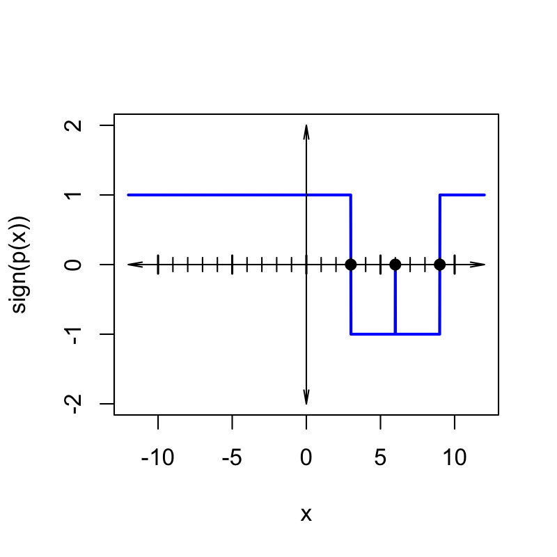

And only one option matches.

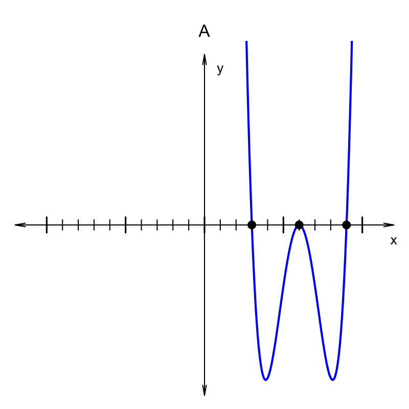

### Graph 1

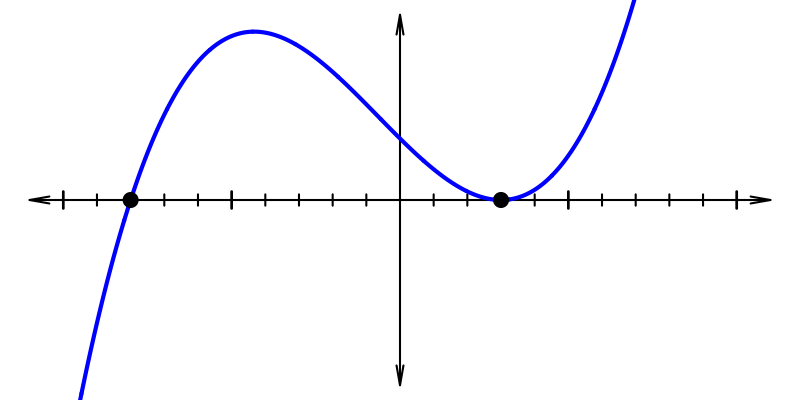

Which function matches Graph 1?

- $A(x)~=~-(x-3)^{2}(x+8)$
- $B(x)~=~(x-3)^{2}(x+8)$
- $C(x)~=~(x-3)^{2}(x+8)^{2}$
- $D(x)~=~(x+3)^{2}(x-8)^{2}$

### Graph 2

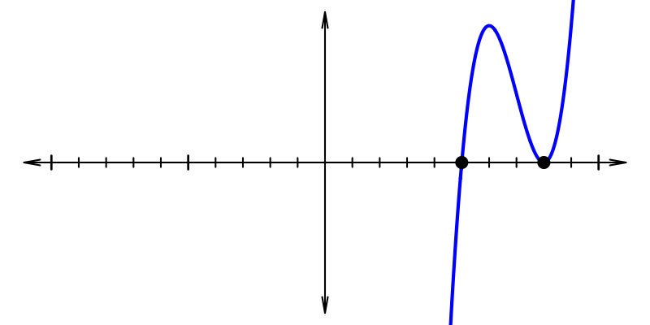

Which function matches Graph 2?

- $A(x)~=~(x-5)(x-8)^{2}$
- $B(x)~=~(x-5)(x+8)$
- $C(x)~=~(x-5)^{2}(x+8)$
- $D(x)~=~(x+5)(x+8)^{2}$

### Graph 3

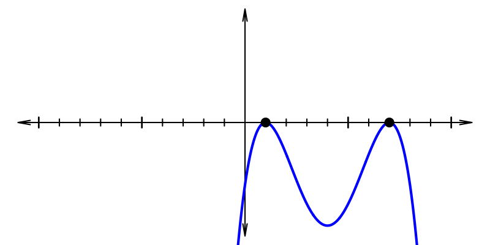

Which function matches Graph 3?

- $A(x)~=~-(x-1)(x-7)^{2}$
- $B(x)~=~-(x-1)^{2}(x-7)^{2}$
- $C(x)~=~(x-1)(x+7)^{2}$
- $D(x)~=~-(x-1)^{2}(x+7)^{2}$
- Graph 1 is $B(x)~=~(x-3)^{2}(x+8)$
- Graph 2 is $A(x)~=~(x-5)(x-8)^{2}$
- Graph 3 is $B(x)~=~-(x-1)^{2}(x-7)^{2}$

Remember, each factor is $(x-r)$ where $r$ is the root. If the factor is squared, we expect a bounce. Lastly, make sure to pay attention to the sign in front, which will dictate the end behavior.

### Graph 1

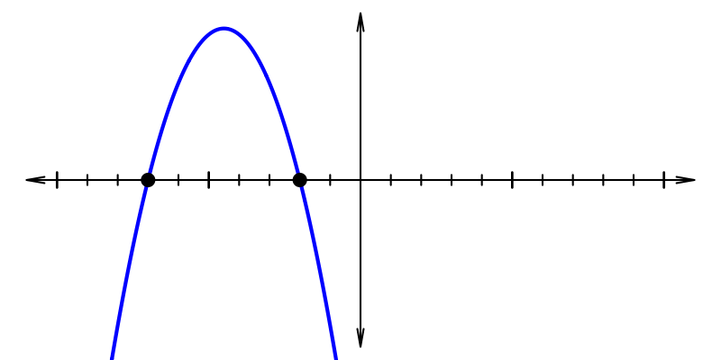

Which function matches Graph 1?

- $A(x)~=~-(x-2)^{2}(x+7)^{2}$
- $B(x)~=~-(x+2)(x-7)$
- $C(x)~=~-(x+2)(x+7)$
- $D(x)~=~-(x+2)^{2}(x+7)^{2}$

### Graph 2

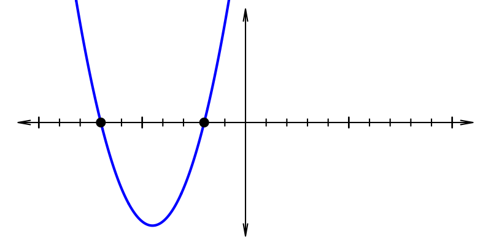

Which function matches Graph 2?

- $A(x)~=~-(x-2)(x-7)^{2}$
- $B(x)~=~(x-2)(x+7)^{2}$
- $C(x)~=~-(x+2)^{2}(x-7)$
- $D(x)~=~(x+2)(x+7)$

### Graph 3

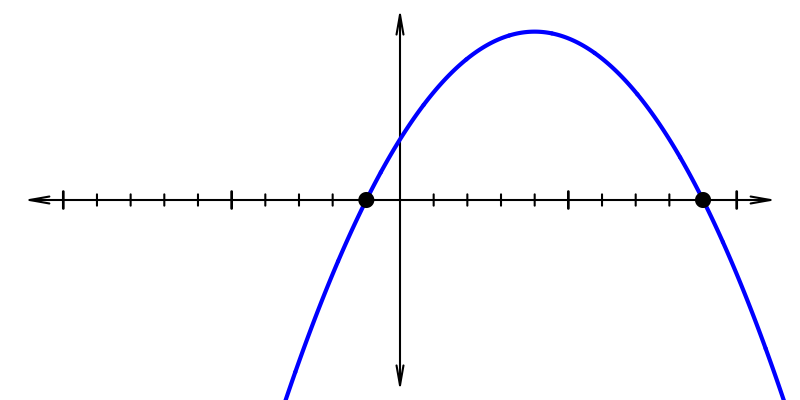

Which function matches Graph 3?

- $A(x)~=~-(x-1)^{2}(x-9)^{2}$
- $B(x)~=~-(x+1)(x-9)$
- $C(x)~=~-(x+1)(x-9)^{2}$
- $D(x)~=~-(x+1)(x+9)$
- Graph 1 is $C(x)~=~-(x+2)(x+7)$
- Graph 2 is $D(x)~=~(x+2)(x+7)$
- Graph 3 is $B(x)~=~-(x+1)(x-9)$

Remember, each factor is $(x-r)$ where $r$ is the root. If the factor is squared, we expect a bounce. Lastly, make sure to pay attention to the sign in front, which will dictate the end behavior.

### Graph 1

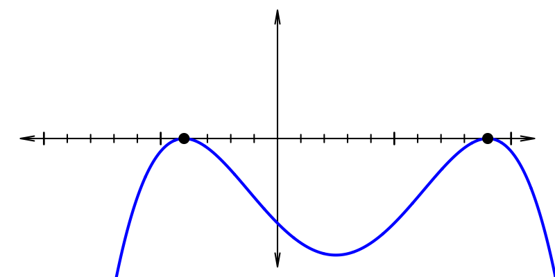

Which function matches Graph 1?

- $A(x)~=~-(x-4)^{2}(x-9)$
- $B(x)~=~-(x-4)^{2}(x+9)^{2}$
- $C(x)~=~-(x+4)^{2}(x-9)$
- $D(x)~=~-(x+4)^{2}(x-9)^{2}$

### Graph 2

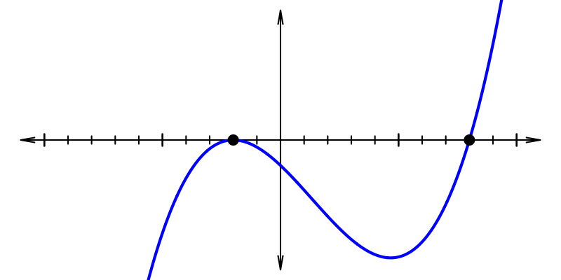

Which function matches Graph 2?

- $A(x)~=~-(x-2)^{2}(x+8)^{2}$
- $B(x)~=~(x+2)(x-8)$
- $C(x)~=~(x+2)^{2}(x-8)$
- $D(x)~=~-(x+2)^{2}(x+8)^{2}$

### Graph 3

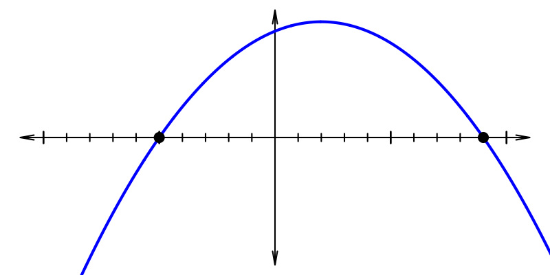

Which function matches Graph 3?

- $A(x)~=~-(x-5)^{2}(x+9)^{2}$
- $B(x)~=~-(x+5)(x-9)$
- $C(x)~=~(x+5)(x-9)^{2}$
- $D(x)~=~-(x+5)^{2}(x-9)^{2}$
- Graph 1 is $D(x)~=~-(x+4)^{2}(x-9)^{2}$
- Graph 2 is $C(x)~=~(x+2)^{2}(x-8)$
- Graph 3 is $B(x)~=~-(x+5)(x-9)$

Remember, each factor is $(x-r)$ where $r$ is the root. If the factor is squared, we expect a bounce. Lastly, make sure to pay attention to the sign in front, which will dictate the end behavior.